# Spatio-temporal variation in zooplankton community composition in the southern Salish Sea: Changes during the 2015–2016 Pacific marine heatwave - ScienceDirect

## [Progress in Oceanography](https://www-sciencedirect-com.reed.idm.oclc.org/journal/progress-in-oceanography)

[Volume 214](https://www-sciencedirect-com.reed.idm.oclc.org/journal/progress-in-oceanography/vol/214/suppl/C), June 2023, 103022

# Spatio-temporal variation in zooplankton community composition in the southern Salish Sea: Changes during the 2015–2016 Pacific marine heatwave

https://doi.org/10.1016/j.pocean.2023.103022[Get rights and content](https://s100.copyright.com/AppDispatchServlet?publisherName=ELS&contentID=S0079661123000654&orderBeanReset=true)

Under a Creative Commons [license](http://creativecommons.org/licenses/by-nc-nd/4.0/)

open access

## Highlights

- •

  Puget Sound zooplankton biomass increased during the [marine heatwave](https://www-sciencedirect-com.reed.idm.oclc.org/topics/earth-and-planetary-sciences/marine-heatwave) of 2015–2016.
- •

  The Salish Sea shows regional variation in zooplankton community composition.
- •

  Salish Sea zooplankton structure driven by different mechanisms than on outer coast.

## Abstract

We examined zooplankton collected across a latitudinal gradient in the southern Salish Sea for changes during the 2015–2016 Pacific marine heatwave (MHW). Zooplankton were collected biweekly in vertical net tows from three regions of Puget Sound and one in northern Washington waters near the Strait of Juan de Fuca, from 2014 to 2020. Water temperatures were cooler in the north and warmer in the south, with anomalously high temperatures occurring in 2015–2016 in all regions. Chlorophyll biomass showed no consistent relationship with temperature. All regions had anomalously high zooplankton biomass in 2015, which continued in the three Puget Sound regions through 2017, with the two central stations showing the most dramatic increases. Several large crustacean species and molluscs showed positive biomass anomalies during the MHW. Euphausiid furcilia showed differential response by species. Puget Sound resident copepod species showed primarily positive anomalies, while some boreal and subarctic copepod species were anomalously low during this period. Gelatinous zooplankton had somewhat higher biomass through the first few years of the study, but patterns showed no clear relationship with the MHW. Differing zooplankton patterns compared to those observed in the California Current, as well as prolonged effects on zooplankton biomass in Puget Sound, suggest that local forcing played a dominant role, likely differing from the mechanisms affecting zooplankton in the California Current. Primary postulated factors include increased growth and metabolism due to higher temperatures, nutrient-driven increases in primary production, and changes in species composition advected from the ocean. Further research is needed to determine the ramifications of the changes and how they may affect the food web in the future.

## Keywords

Zooplankton

Pacific marine heatwave

Copepods

Euphausiids

Gelatinous zooplankton

Marine ecology

Environmental effects

USA

Washington

Salish Sea

Puget Sound

## 1. Introduction

A mass of anomalously warm water, initially termed “The Blob” (Bond et al., 2015), developed in the Northeast (NE) Pacific Ocean in winter 2013, leading to the largest marine heatwave (MHW) on record in this region (Di Lorenzo and Mantua, 2016), with the highest sea level pressure anomalies since the 1940s (Bond et al., 2015). These high temperatures impacted the coastal ocean beginning in fall 2014 and persisted through the 2015–2016 [El Niño](https://www-sciencedirect-com.reed.idm.oclc.org/topics/earth-and-planetary-sciences/el-nino) (Di Lorenzo and Mantua, 2016, Jacox et al., 2019). The Salish Sea, which connects to the NE Pacific through the Strait of Juan de Fuca into the estuarine basins of Puget Sound, Washington (USA) and the Strait of Georgia, British Columbia (Canada), experienced the strongest effects of the MHW in 2015 and 2016, with anomalous warming of the full water column, as well as other environmental changes (Chandler et al., 2017, PSEMP Marine Waters Workgroup, 2017, Khangaonkar et al., 2021). This large ocean climate event had broad ecological effects across the NE Pacific region, and may provide insight into future conditions caused by [climate change](https://www-sciencedirect-com.reed.idm.oclc.org/topics/agricultural-and-biological-sciences/climate-change).

Zooplankton play a major role in [marine ecosystems](https://www-sciencedirect-com.reed.idm.oclc.org/topics/agricultural-and-biological-sciences/aquatic-ecosystem), transferring energy from primary producers up through the food web. They are important prey for forage fish, juvenile salmon, seabirds, and baleen whales (Peterson et al., 2017, Hipfner et al., 2020). This influence reaches apex predators, such as NE Pacific resident killer whales, which depend on [Chinook salmon](https://www-sciencedirect-com.reed.idm.oclc.org/topics/agricultural-and-biological-sciences/oncorhynchus-tshawytscha) for survival (Ford et al., 2010). Zooplankton are also good indicators of ecosystem change. Their relatively short generation times, lack of a fishing harvest, and limited range of movement through the environment allow them to closely track environmental changes (Mackas et al., 2001, Mackas and Beaugrand, 2010, Batten et al., 2018). An example of this is in the Northern California Current (NCC), where certain species of copepods are associated with southern and offshore warm waters, while others (usually more lipid-rich) are associated with cold, boreal waters. Shifts in this zooplankton species composition have been linked to seasonal and multi-year, climate-driven changes (Mackas et al., 2006, Keister et al., 2011) and strongly correlate with salmon survival (Pugh, 1999, Bi et al., 2011a, Bi et al., 2011b). Biomass is also an important factor, such as in the Strait of Georgia, where total zooplankton biomass and calanoid copepod biomass were found to be significant predictors of [coho salmon](https://www-sciencedirect-com.reed.idm.oclc.org/topics/agricultural-and-biological-sciences/oncorhynchus-kisutch) early marine survival (Araujo et al., 2013).

Impacts of the 2014–2016 MHW on zooplankton have been reported in the NE Pacific from [Mexico](https://www-sciencedirect-com.reed.idm.oclc.org/topics/earth-and-planetary-sciences/mexico) to the Gulf of Alaska. In the Southern California Current System (SCC), surface temperatures were anomalously high, with lower nearshore salinity, anomalous periods of downwelling, and evidence of decreased chlorophyll concentration (Zaba and Rudnick, 2016). Calanoid copepods, hyperiid [amphipods](https://www-sciencedirect-com.reed.idm.oclc.org/topics/agricultural-and-biological-sciences/amphipoda), and larvaceans all decreased off southern California during the MHW (Lilly and Ohman, 2018). Upwelling-associated euphausiids decreased or were displaced, while tropical and subtropical species increased (Lilly and Ohman, 2018, Lilly and Ohman, 2021; Lavaniegos et al., 2019). Similar physical changes were seen in the NCC associated with a northern displacement of the North Pacific Current (Peterson et al., 2017, Fisher et al., 2020). An overall decrease in crustacean zooplankton (shrimp, euphausiids, amphipods, and copepods), an increase in gelatinous zooplankton, and species shifts were reported, including the appearance of relatively rare subtropical species off the Oregon coast (Peterson et al., 2017, Brodeur et al., 2019, Morgan et al., 2019). Although some studies found decreases in euphausiids (Peterson et al., 2017, Brodeur et al., 2019), the early life stages of *[Euphausia pacifica](https://www-sciencedirect-com.reed.idm.oclc.org/topics/agricultural-and-biological-sciences/euphausia-pacifica)* increased in 2014 in the NCC and was exceptionally high in 2015 compared to the previous 15 years (Morgan et al., 2019).

Farther north, on the coastal margin of B.C. where zooplankton have been monitored since 1979, some patterns in zooplankton populations observed during the MHW were similar to those in the [CCS](https://www-sciencedirect-com.reed.idm.oclc.org/topics/earth-and-planetary-sciences/carbon-capture-and-storage), while others contrasted. As in the NCC, higher densities of warm-water copepods and lower densities of cold-water copepods were observed in the [continental shelf](https://www-sciencedirect-com.reed.idm.oclc.org/topics/earth-and-planetary-sciences/continental-shelf) and offshore waters of B.C. during the warm years of 2014–2016 (Chandler et al., 2016, Chandler et al., 2017). This region also experienced increased densities of gelatinous zooplankton, resulting in a higher ratio of gelatinous zooplankton to crustaceans. In contrast to the CCS, there were higher densities of euphausiids off B.C. during this period, although the increase began before the MHW (Chandler et al., 2016, Chandler et al., 2017). In the Gulf of Alaska, higher than average zooplankton biomass was seen in 2014 and 2015, including that of copepods, euphausiids, hyperiid amphipods, and pteropods (Batten et al., 2018). Throughout the NCC, the B.C. [continental shelf](https://www-sciencedirect-com.reed.idm.oclc.org/topics/agricultural-and-biological-sciences/continental-shelf), the Salish Sea, and the Gulf of Alaska, a dominant warm-water copepod (*[Calanus](https://www-sciencedirect-com.reed.idm.oclc.org/topics/agricultural-and-biological-sciences/calanus)* *pacificus*) was anomalously abundant during the warm years of 2014–2016, whereas a cold-water species (*[Acartia](https://www-sciencedirect-com.reed.idm.oclc.org/topics/agricultural-and-biological-sciences/acartia)* *longiremis*) showed negative anomalies (Fisher et al., 2020).

Little has been reported about shifts in zooplankton during the MHW in the Salish Sea. In addition to anomalously high temperatures throughout the water column, this region experienced rapid, early snowmelt and river discharge, causing low salinity. This led to early stratification and an anomalously early spring phytoplankton bloom in 2015, followed by drought and high salinity in the summers of 2015–2016 (Chandler et al., 2017, PSEMP Marine Waters Workgroup, 2017). In the Strait of Georgia, total zooplankton biomass was also anomalously high, and *Calanus pacificus* increased in biomass dominance, in 2014–2016 (Perry et al., 2021). Other species patterns have not been reported in detail from the northern Salish Sea.

The southern Salish Sea is comprised of the U.S. waters of the Strait of Juan de Fuca, Northern Washington and the San Juan Islands, and Puget Sound. Admiralty Inlet is the entrance to Puget Sound, which is separated into four primary basins: Whidbey Basin, Hood Canal, Central Basin, and South Sound. The MHW caused unprecedented warming in Puget Sound, at times exceeding 2 °C above the observed 10-year average (PSEMP, 2016). Systematic monitoring of zooplankton began in 2014, providing the first data available to evaluate climate impacts. In contrast to patterns observed in the CCS, early reports indicated that zooplankton biomass was elevated in the southern Salish Sea during the MHW years (PSEMP, 2017). Ecological modeling found that biomass increased by ∼ 18% overall in response to elevated phytoplankton production during that period (Khangaonkar et al., 2021). In this study, we used environmental and zooplankton data collected from before, during, and after the MHW to explore patterns in four regions of the southern Salish Sea representing a gradient in ocean-influence: the San Juan Islands in the northeastern Strait of Juan de Fuca; Admiralty Inlet, the well-mixed entrance to Puget Sound; Central Basin; and South Sound, a retentive basin that is partially separated from Central Basin by a sill at the Tacoma Narrows.

## 2. Materials and methods

### 2.1. Field methods

Sampling was conducted approximately bi-weekly in spring through fall 2014–2020 and monthly through winter when possible at sites in the San Juan Islands (SJI; 48.4346°N, 122.8037°W; 33 m depth), Admiralty Inlet (ADM; 48.0027°N, 122.636°W; 124 m depth), Central Basin (CB; 47.7440°N, 122.4282°W, 275 m depth), and South Sound (SS; 47.1524°N, 122.6586°W; 130 m depth) (Fig. 1). Zooplankton were collected as part of the Salish Sea Marine Survival Project (SSMSP) by scientists from federal, state, and county agencies, tribes, and nonprofit organizations following rigorous, identical protocols. In 2020, ADM and SS were not sampled in April and May, and CB was not sampled from April until mid-June due to the COVID-19 pandemic. At each station, net tows were conducted using a 60-cm diameter, 200-μm mesh single ring net, lifted vertically from 5 to 10 m off the bottom (from a maximum of 200 m depth) to the surface at 0.5 m/s. TSK [flow meters](https://www-sciencedirect-com.reed.idm.oclc.org/topics/agricultural-and-biological-sciences/flowmeter) were used to measure the volume of water filtered. All samples were preserved in 5% buffered formalin in seawater and stored until processed in the laboratory.

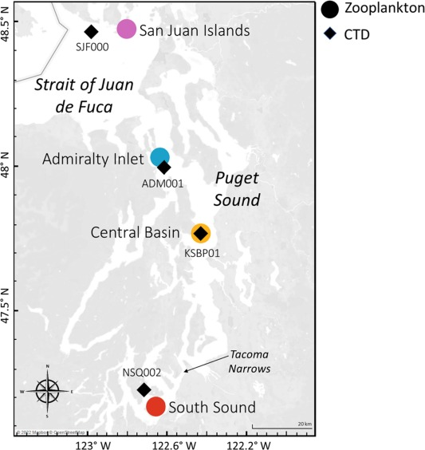

1. [Download: Download high-res image (267KB)](https://ars-els-cdn-com.reed.idm.oclc.org/content/image/1-s2.0-S0079661123000654-gr1_lrg.jpg)
2. [Download: Download full-size image](https://ars-els-cdn-com.reed.idm.oclc.org/content/image/1-s2.0-S0079661123000654-gr1.jpg)

Fig. 1. Map of sampling stations where zooplankton (colored circles) and CTD data (black diamonds) were collected.

Hydrographic data came from monitoring conducted monthly since 1989 by the Washington State Department of Ecology (DOE) and bi-weekly since 1998 by King County. Stations located at or nearest to the zooplankton sites were selected. King County data collected at the CB zooplankton site were used for Central Basin. Department of Ecology data were used for all other sites: SJF00 (48.4167°N, 123.025°W) for SJI, ADM001 (48.0298°N, 122.6179°W) for ADM, and NSQ002 (47.1673°N, 122.7882°W) for SS (Fig. 1). At each site, CTD profiles were collected using a Sea-Bird SBE 3 CTD equipped with a WET Labs WETStar Fluorometer (King County) or WET Labs ECO-FL-NTU (DOE) to measure fluorescence. Annual calibration of King County’s fluorometer was conducted by the manufacturer (King County, 2020) whereas DOE annually calibrated their fluorometer using Niskin bottle samples collected from 10 m and 30 m depths (Bos and Keyzers, 2021, Bos, 2022). The WET Labs ECO-FL-NTU was calibrated against Chl*a* (µg L<sup>-1</sup>), whereas King County’s fluorometer was calibrated to total chlorophyll; for the purposes of streamlining terminology, all chlorophyll data here will be referred to as Chl*a* (µg L<sup>-1</sup>).

### 2.2. Laboratory methods

Zooplankton samples were examined under a dissecting microscope for taxonomic composition, abundance, and size measurements. First, rare larger organisms (usually > 1 cm) were removed from the entire sample for identification and measurement. When densities were very high, samples were first split with a Folsom splitter. Two small (1-mL) aliquots were then quantitatively extracted for analysis from the whole (or split) sample using a Stempel pipette. Finally, a larger aliquot (at least 10 mL) was taken to quantify mid-sized taxa not adequately subsampled by smaller aliquots. All heterotrophic organisms in the subsamples were enumerated, identified, and differentiated by life history stage when possible, using morphological characteristics. A minimum of 400 individuals were identified in each sample. For organisms which vary greatly in size within a life stage, up to 30 individuals were measured per sample to convert size to biomass.

### 2.3. Statistical methods

[Temperature anomalies](https://www-sciencedirect-com.reed.idm.oclc.org/topics/earth-and-planetary-sciences/temperature-anomaly) were calculated by creating a mean monthly profile for each station, which was then subtracted from the individual observed values across all sampling dates for the corresponding station and month. Average 0.5–3 m surface temperature anomalies are shown. Chlorophyll-*a* anomalies were similarly calculated except the upper 3–30 m averaged values are shown.

The density of organisms (# of individuals m<sup>−3</sup>) was calculated from sample counts using the volume of water filtered by each net tow. Biomass (in carbon) of measured taxa (larger taxa and those that tend to vary greatly in size within a life stage) were calculated from density either using length:weight or length:carbon relationships reported in the literature (Williams and Robins, 1979, Webber and Roff, 1995, Lavaniegos and Ohman, 2007), and for small, unmeasured organisms, from carbon conversions by species and life stage taken from the literature (Uye, 1982, Lavaniegos and Ohman, 2007). Very large organisms or life history stages that can easily avoid vertical net tows, such as large shrimp or adult euphausiids, and were therefore not quantitatively sampled, were removed from analyses.

To calculate biweekly zooplankton (total or individual taxon) biomass anomalies for each region, values across all years (2014–2020) were averaged in each calendar month to establish the monthly-averaged seasonal cycle (climatology) for each site. These monthly averages were then subtracted from the observed total biomass value from each sample that fell within that month. Annual total biomass anomalies were likewise calculated by averaging the total biomass among all samples, then subtracting that value from the average total biomass of the samples for each year. No adjustment was made to account for missing samples before collections began at each site in early 2014 or during the COVID-19 shutdown in spring 2020.

To explore changes that occurred during the main period of the MHW, we compared 2015–2016 to all other years in the study. Unless otherwise noted, percentage changes in biomass are reported as the average biomass in samples collected during MHW years (2015–2016) relative to non-MHW years (2014, 2017–2020). Only May-September samples were used in these calculations because those months were the most consistently sampled at all sites every year. No correction was applied for missed sampling in spring 2020 at ADM, CB, and SS, which may affect those 2020 annual averages.

## 3. Results

### 3.1. Environmental data

Temperature profiles show a [latitudinal gradient](https://www-sciencedirect-com.reed.idm.oclc.org/topics/earth-and-planetary-sciences/latitudinal-gradient) of cooler waters in the north to much warmer waters in south Puget Sound (Fig. 2). Strong seasonal cycles were apparent at each site. At the northern site (SJI), anomalously warm near-surface temperatures were first observed in July 2014 and persisted through the end of 2016, followed by mostly cooler temperatures in 2017–2020. Consistent warm anomalies occurred slightly later at ADM and CB in the fall, (although May 2014 was high at ADM) reaching very high anomalies in 2015–2016. Temperatures were low in fall and winter 2016, returning to some moderately positive anomalies in summer 2017, lingering through the fall at ADM before generally decreasing through most of 2018. At the southernmost station (SS), consistent high temperature anomalies began in late fall 2014, which continued through 2016 and were followed by low anomalies in 2017. All stations showed a return of colder winter temperatures at the beginning of 2017.

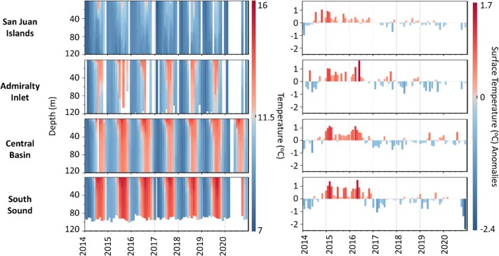

1. [Download: Download high-res image (377KB)](https://ars-els-cdn-com.reed.idm.oclc.org/content/image/1-s2.0-S0079661123000654-gr2_lrg.jpg)
2. [Download: Download full-size image](https://ars-els-cdn-com.reed.idm.oclc.org/content/image/1-s2.0-S0079661123000654-gr2.jpg)

Fig. 2. Temperature at each station, showing monthly average depth profiles (left panels) and non-seasonal monthly averaged surface (0.5–3 m) [temperature anomalies](https://www-sciencedirect-com.reed.idm.oclc.org/topics/earth-and-planetary-sciences/temperature-anomaly) (right panels). Blanks represent missed sampling.

Overall, Chl*a* was lowest at SJI and highest at ADM and CB (Fig. 3). Note, however, that fluorometer calibration differences could bias levels at CB slightly high relative to the other stations. Chl*a* showed strong seasonal cycles at all sites. Fairly high positive Chl*a* anomalies occurred at some point at all sites in 2014. Anomalies were mixed during the MHW years. SJI and SS had mostly anomalously high Chl*a* throughout 2015, whereas ADM was anomalously high in the spring and low in the summer, and CB was mixed. In 2016, all regions had mixed Chl*a* anomalies in spring, except for ADM, which was low. By summer of 2016, ADM and CB had mostly positive Chl*a* anomalies, while the other stations had a mix. Chl*a* at all sites was low in early 2017, shifting to some positive anomalies in spring or summer at stations in Puget Sound, but remaining low at SJI until fall. Chl*a* was primarily low with a few high anomalies in 2018, except at ADM, which was mostly high, with a large negative anomaly in spring. Chl*a* at the two southern sites were near average in 2019, while anomalies were mostly positive at SJI and negative at ADM. Chl*a* was low in months that were sampled in 2020, except at CB, where anomalies were mixed in summer and low in the fall. The DOE sites may be biased in 2020 due to sporadic sampling.

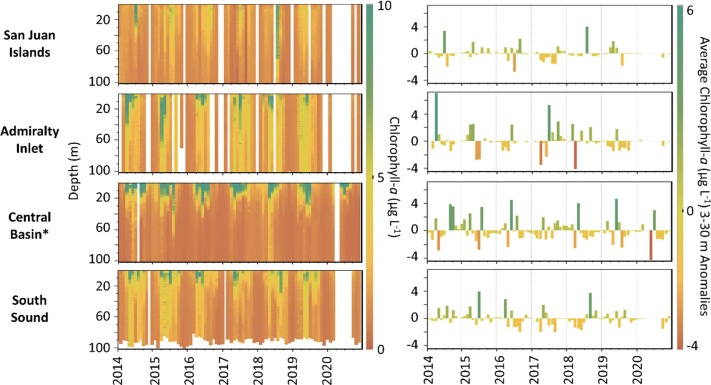

1. [Download: Download high-res image (401KB)](https://ars-els-cdn-com.reed.idm.oclc.org/content/image/1-s2.0-S0079661123000654-gr3_lrg.jpg)
2. [Download: Download full-size image](https://ars-els-cdn-com.reed.idm.oclc.org/content/image/1-s2.0-S0079661123000654-gr3.jpg)

Fig. 3. Chlorophyll-*a* at each station, showing the monthly averaged depth profiles (left panels) and non-seasonal monthly averaged 3–30 m chlorophyll-*a* (right panels). Blanks represent missed sampling. *Central Basin units are in chlorophyll (µg L<sup>-1</sup>), not chlorophyll-*a*.

### 3.2. Total zooplankton biomass

A strong seasonal cycle in total zooplankton biomass occurred in all regions (Fig. 4 and S1). Central Basin had consistently high biomass compared to other sites, with the exception of very high biomass observed in Admiralty Inlet in May of 2015–2017. The San Juan Island region had the lowest biomass overall.

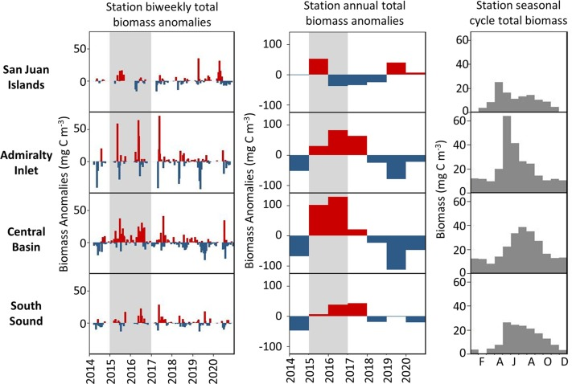

1. [Download: Download high-res image (367KB)](https://ars-els-cdn-com.reed.idm.oclc.org/content/image/1-s2.0-S0079661123000654-gr4_lrg.jpg)
2. [Download: Download full-size image](https://ars-els-cdn-com.reed.idm.oclc.org/content/image/1-s2.0-S0079661123000654-gr4.jpg)

Fig. 4. Total zooplankton biomass anomalies from the seasonal cycle (left panels), annual total biomass anomalies (middle panels), and the average seasonal cycle in total biomass (right panels). Blanks represent missing samples.

Zooplankton biomass patterns varied regionally during MHW years. All sites showed primarily positive biomass anomalies in 2015. In 2016, biomass increased at sites within Puget Sound (ADM, CB, and SS) in 2016–2017, whereas biomass was moderately low at SJI. The positive anomalies at SS lagged slightly behind other regions, reaching its most positive annual anomaly in 2017.

At SJI, the most ocean-influenced region, peak biomass doubled from 2014 to 2015, and occurred in fall rather than spring (Figure S1). However, the highest biomass at SJI (causing positive annual anomalies) was observed in April 2019 and 2020, as described below. Admiralty Inlet had the overall highest biomass values during the MHW, occurring each May 2015–2017; these values were almost triple the highest 2014 biomass, and were mostly due to a high abundance of larval crabs. Biomass at CB was also elevated in 2015–2017, about double its 2014 maximum. Values at CB decreased through 2019, when the lowest biomass for the site occurred. At SS, changes during the MHW appeared delayed compared to other sites; anomalies were positive in 2015, but were higher in 2016–2017. Sampling at the Puget Sound stations was missed due to the pandemic in spring of 2020, a season when biomass usually starts to increase. This might have biased the 2020 annual averages low, but wouldn’t affect patterns among other years. The lack of these spring data for calculating the seasonal cycle also wouldn’t have likely have a large impact on the overall anomaly patterns.

### 3.3. Taxon-specific patterns

#### 3.3.1. Taxa with positive anomalies during the MHW

Many crustacean zooplankton increased in total biomass or were anomalously high across multiple regions during the warm years, including [amphipods](https://www-sciencedirect-com.reed.idm.oclc.org/topics/agricultural-and-biological-sciences/amphipoda), crab larvae, shrimp, and [mysids](https://www-sciencedirect-com.reed.idm.oclc.org/topics/agricultural-and-biological-sciences/mysida) (Fig. 5a and S2a). Amphipods, which were most abundant in Central Basin, increased by up to 95% in MHW years, and were anomalously high at SJI as early as late summer 2014. Crab larvae, which were particularly abundant at ADM, dramatically increased by 85% during the MHW, and remained high through 2017. At CB and SJI, crab biomass increased in 2015, but were even more abundant in later years. Shrimp biomass increased during MHW years, except in Admiralty Inlet, where there was a slight decrease (-9%); the highest average increase during MHW years was 105% in South Sound. All of these taxa were found in the majority of samples, except for mysids (Table S1). Mysids were most commonly found in Admiralty Inlet and South Sound. Their average annual biomass rose during MHW years in all regions, most dramatically at SJI by > 35x, where they were normally less common (Fig. S2a, Table S1).

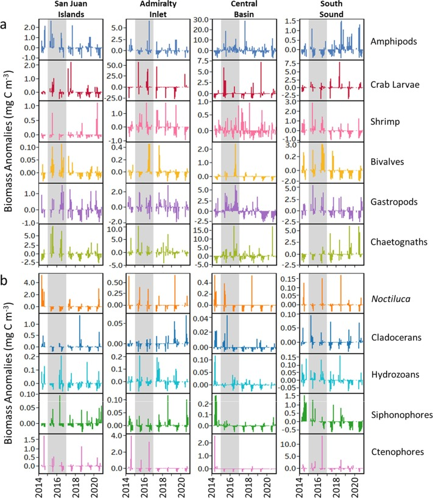

1. [Download: Download high-res image (920KB)](https://ars-els-cdn-com.reed.idm.oclc.org/content/image/1-s2.0-S0079661123000654-gr5_lrg.jpg)
2. [Download: Download full-size image](https://ars-els-cdn-com.reed.idm.oclc.org/content/image/1-s2.0-S0079661123000654-gr5.jpg)

Fig. 5. a) Biweekly biomass anomalies of taxa with mostly positive responses and b) mostly negative or mixed responses to the 2015–2016 Pacific [marine heatwave](https://www-sciencedirect-com.reed.idm.oclc.org/topics/earth-and-planetary-sciences/marine-heatwave).

Planktonic stages of some common molluscs also increased during the MHW years (Fig. S2a and 5a). Overall, bivalves and gastropods, which were most abundant at the three Puget Sound sites, were strongly elevated during at least one of the MHW years. The highest % changes occurred in Central Basin, where bivalves and gastropods increased 402% and 165%, respectively.

Other taxa that increased in all regions during 2015–2016 included [polychaetes](https://www-sciencedirect-com.reed.idm.oclc.org/topics/agricultural-and-biological-sciences/polychaete) and [bryozoans](https://www-sciencedirect-com.reed.idm.oclc.org/topics/earth-and-planetary-sciences/bryozoan) (Fig. S2a). South Sound saw an 87% rise in polychaetes, while SJI had a 102% increase in [bryozoans](https://www-sciencedirect-com.reed.idm.oclc.org/topics/agricultural-and-biological-sciences/bryozoa). Annual biomass of [chaetognaths](https://www-sciencedirect-com.reed.idm.oclc.org/topics/agricultural-and-biological-sciences/chaetognatha) (Fig. S2a and 5a), echinoderms, and [fish larvae](https://www-sciencedirect-com.reed.idm.oclc.org/topics/agricultural-and-biological-sciences/fish-larvae) (Fig. S2a) also increased, except at SS. Chaetognath biomass averaged 169% higher at SJI and 88% at CB; echinoderms increased 83% at ADM and 71% at CB; and fish larvae increased by 162% at SJI, 134% at ADM, and 873% at CB. Biomass at SS decreased by 41–65% for these three taxa during MHW years.

#### 3.3.2. Taxa with negative anomalies during the MHW

Few taxa showed clear decreases in abundance or biomass during the warm years (Fig. 5b and S2b). The decreases were often regional in areas where the organism was most dominant. For example, [cladocerans](https://www-sciencedirect-com.reed.idm.oclc.org/topics/agricultural-and-biological-sciences/cladocera) and the heterotrophic dinoflagellate *[Noctiluca](https://www-sciencedirect-com.reed.idm.oclc.org/topics/agricultural-and-biological-sciences/noctiluca)* declined in most regions during the MHW. *Noctiluca* was at or close to its peak biomass at all sites in 2014, and decreased at all sites in 2015. Average biomass during the MHW years dropped by 91% at SJI (where abundance was overall highest); and decreased slightly at other stations, except ADM. Cladocerans, also most abundant at SJI, were reduced in average biomass (69% at SJI and 22% at ADM) during MHW years, and at CB after 2015. These taxa both occurred most commonly at SJI (Table S1).

#### 3.3.3. Taxonomic groups with mixed patterns during the MHW

Biomass of gelatinous zooplankton (hydromedusae, siphonophores, and ctenophores) varied among years and basins (Fig. 5b, 6, and S2b). South Sound consistently had the highest biomass and occurrence of gelatinous zooplankton while Central Basin usually had the lowest (Table S1). Changes in annually-averaged biomass were mostly negative in MHW years, with the exceptions of [hydrozoans](https://www-sciencedirect-com.reed.idm.oclc.org/topics/agricultural-and-biological-sciences/hydrozoa).

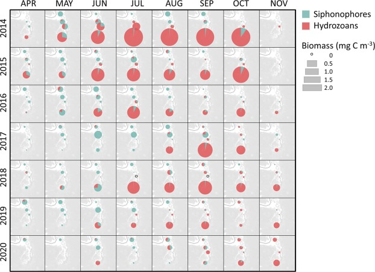

1. [Download: Download high-res image (404KB)](https://ars-els-cdn-com.reed.idm.oclc.org/content/image/1-s2.0-S0079661123000654-gr6_lrg.jpg)
2. [Download: Download full-size image](https://ars-els-cdn-com.reed.idm.oclc.org/content/image/1-s2.0-S0079661123000654-gr6.jpg)

Fig. 6. [Gelatinous zooplankton](https://www-sciencedirect-com.reed.idm.oclc.org/topics/agricultural-and-biological-sciences/gelatinous-zooplankton) biomass (hydrozoans and siphonophores) mapped over all regions from 2014 to 2020. Biomass values averaged by month. [Ctenophores](https://www-sciencedirect-com.reed.idm.oclc.org/topics/agricultural-and-biological-sciences/ctenophora) were excluded from this figure because sporadic high abundances overwhelmed the biomass. Small black circles indicate locations where samples were collected but zero individuals were found. Scale bars in legend indicate diameter of biomass symbols.

(+60%) and [ctenophores](https://www-sciencedirect-com.reed.idm.oclc.org/topics/agricultural-and-biological-sciences/ctenophora) (+176%) at SS, and siphonophores at SJI (+137%). However, many of the mean declines relative to non-MHW years may have been driven by exceptionally high biomass that occurred in 2014, leading to low anomalies in 2015–2016. If 2014 was included with 2015–2016, taxa increased at all sites relative to the later years, except at ADM. Larvaceans also showed mixed changes (Fig. S2a), with average annual biomass during the MHW years increasing only in the south at CB (39%) and SS (17%).

Biomass of euphausiid furcilia was highest in Admiralty Inlet and Central Basin (Fig. 7, Fig. 8). *Euphausia pacifica* was the dominant species at all stations, although *[Thysanoessa](https://www-sciencedirect-com.reed.idm.oclc.org/topics/agricultural-and-biological-sciences/thysanoessa)* *raschii* was sometimes important in May-June. These species showed contrasting patterns during the MHW. *E. pacifica* furcilia increased about twofold, with high positive anomalies in at least one of the MHW years in all regions, dropping to negative anomalies for the following two years. In contrast, *Thysanoessa raschii* furcilia biomass was anomalously low in all regions throughout the MHW, with positive anomalies occurring at all stations in 2017.

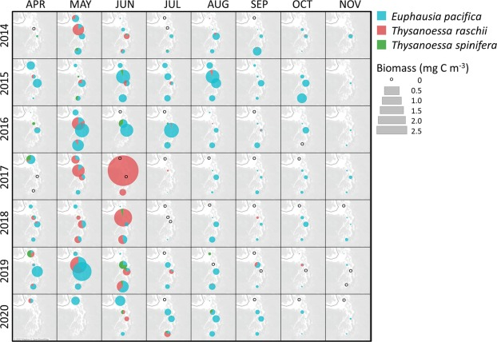

1. [Download: Download high-res image (415KB)](https://ars-els-cdn-com.reed.idm.oclc.org/content/image/1-s2.0-S0079661123000654-gr7_lrg.jpg)
2. [Download: Download full-size image](https://ars-els-cdn-com.reed.idm.oclc.org/content/image/1-s2.0-S0079661123000654-gr7.jpg)

Fig. 7. Average monthly biomass of [euphausiid](https://www-sciencedirect-com.reed.idm.oclc.org/topics/agricultural-and-biological-sciences/krill) furcilia mapped at each site from 2014 to 2020. Symbol size is proportional to biomass, colored by proportion of each species. Small black circles indicate locations where samples were collected but had zero furcilia. The peak euphausiid season may have been missed in spring 2020 due to suspended sampling. Scale bars in legend indicate diameter of biomass symbols.

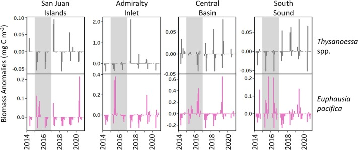

1. [Download: Download high-res image (246KB)](https://ars-els-cdn-com.reed.idm.oclc.org/content/image/1-s2.0-S0079661123000654-gr8_lrg.jpg)
2. [Download: Download full-size image](https://ars-els-cdn-com.reed.idm.oclc.org/content/image/1-s2.0-S0079661123000654-gr8.jpg)

Fig. 8. Biomass anomalies of *[Thysanoessa](https://www-sciencedirect-com.reed.idm.oclc.org/topics/agricultural-and-biological-sciences/thysanoessa)* spp. furcilia (gray bars in top panels) and *[Euphausia pacifica](https://www-sciencedirect-com.reed.idm.oclc.org/topics/agricultural-and-biological-sciences/euphausia-pacifica)* furcilia (pink bars in lower panels) at each site.

Several of the dominant species of copepods in Puget Sound increased in biomass overall, or peaked earlier in the season, during the MHW years. Three of these (the calanoids *[Calanus](https://www-sciencedirect-com.reed.idm.oclc.org/topics/agricultural-and-biological-sciences/calanus)* *pacificus*, *Paracalanus spp*., and cyclopoid *Ditrichocorycaeus anglicus*) were most abundant at CB and least abundant at SJI (Fig. S3a, Table S1). All three species had primarily positive anomalies during MHW years (Fig. 9a), with the largest increases observed at SJI (280% for *C. pacificus*, 42% for *Paracalanus spp*., and 81% for *D. anglicus*).

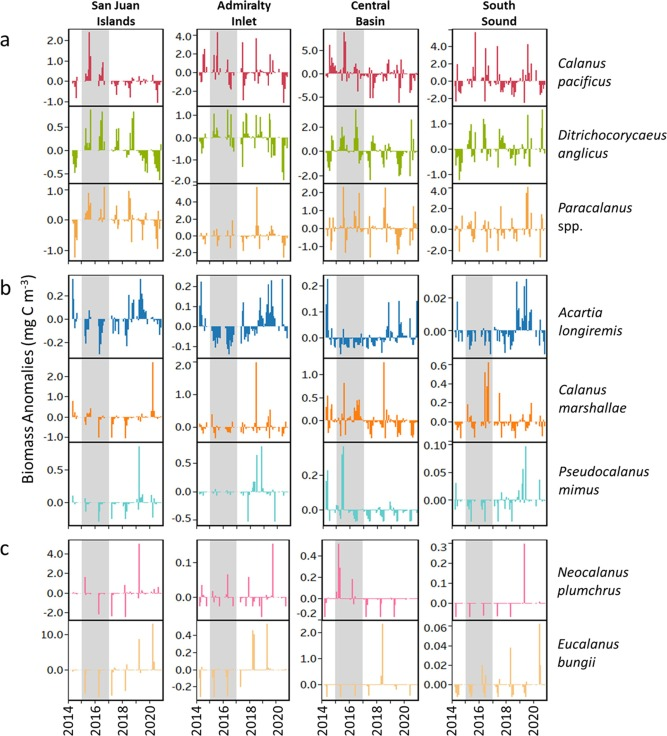

1. [Download: Download high-res image (646KB)](https://ars-els-cdn-com.reed.idm.oclc.org/content/image/1-s2.0-S0079661123000654-gr9_lrg.jpg)
2. [Download: Download full-size image](https://ars-els-cdn-com.reed.idm.oclc.org/content/image/1-s2.0-S0079661123000654-gr9.jpg)

Fig. 9. a) Biweekly biomass anomalies of puget sound resident copepod species, b) boreal copepod species, and c) subarctic copepod species by region.

A group of calanoid copepods that are dominant on the [continental shelf](https://www-sciencedirect-com.reed.idm.oclc.org/topics/agricultural-and-biological-sciences/continental-shelf) during coastal upwelling (*[Acartia](https://www-sciencedirect-com.reed.idm.oclc.org/topics/agricultural-and-biological-sciences/acartia)* *longiremis*, *Pseudocalanus* *mimus**,* and *Calanus marshallae*), but are not typically abundant in our study region, had overall higher biomass in the north (SJI) and lowest in the south (SS). Most of these species were less abundant during the MHW years, although there were exceptions at the two southern stations where they are typically rare (Fig. 9b and S3b). *A. longiremis* decreased 38–64% during MHW years at all stations. *P. mimus*, which was not commonly abundant at any station (Table S1), decreased 51–98% during MHW years at all stations except CB, where they increased by 672% from 0.05 to 0.41 mg C m<sup>−3</sup> due to two anomalously high values of 0.77 and 0.86 mg C m<sup>−3</sup> in summer 2015 collections. In contrast, *C. marshallae* increased during MHW years at CB (145% increase from 0.15 to 0.37 mg C m<sup>−3</sup>) and SS (271% increase from 0.04 to 0.15 mg C m<sup>−3</sup>). They increased at SJI by 66%, but this calculation does not include high values of 2.4–5.5 mg C m<sup>−3</sup> in April 2019 and 2020, respectively. The strongest positive anomalies for all three of these species predominantly occurred at the two northern sites from 2018 to 2020.

## 4. Discussion

### 4.1. Environmental changes

The basins of Puget Sound and Northern Washington vary in characteristics such as ocean influence, [freshwater input](https://www-sciencedirect-com.reed.idm.oclc.org/topics/earth-and-planetary-sciences/freshwater-input), depth, mixing, and residence times. These lead to regional differences in response to [climate variability](https://www-sciencedirect-com.reed.idm.oclc.org/topics/earth-and-planetary-sciences/climate-variation), making Puget Sound a dynamic region in which to study climate effects. As expected, a strong temperature gradient of cooler water in the north to warmer water in the south was observed, which also corresponds with greater distance from the ocean and longer residence times. The SJI site is heavily influenced by the connection to the NE Pacific via the Strait of Juan de Fuca and to the Fraser River in the southern Strait of Georgia (Moore et al., 2008). The Strait of Juan de Fuca brings in cold, nutrient-rich ocean water, while the Fraser River carries substantial snowmelt runoff into the basin in warmer months. Water in Admiralty Inlet has a very short residence time, a narrow seasonal temperature range, and is kept cool from tidal mixing over the sills (Moore et al., 2008). South Sound is the shallowest of the basins and has the largest seasonal temperature range. It has areas of high mixing near the Tacoma Narrows, as well as very stratified finger inlets (Moore et al., 2008). SJI was the first of our regions to experience very positive temperature anomalies in the summer of 2014, before the MHW warmed coastal waters that fall. This suggests that the initial temperature increase was not due to advection from the ocean, but due to increased solar radiation and atmospheric warming reported in summer 2014 (PSEMP, 2015). The other three regions followed, and all stations were anomalously warm through 2016, similar to coastal conditions.

Our chlorophyll-*a* (Chl*a*) data showed mixed patterns during the MHW, with some positive anomalies in spring and/or summer in all regions in 2015, supporting other studies in the Salish Sea which reported early stratification and early phytoplankton blooms in Central Basin (PSEMP, 2016) and the Strait of Georgia (Chandler et al., 2017). Patterns in 2016 differed from 2015, with early and short blooms in some locations in Puget Sound, and smaller or absent fall blooms (PSEMP, 2017). Simulations of a numerical model suggested that higher freshwater input amplified estuarine exchange flow before and during the MHW, bringing in more oceanic nutrients and increasing production and food availability for zooplankton by an estimated 14% and 6% in 2015 and 2016, respectively (Khangaonkar et al., 2021). While the 2015 and 2016 Chl*a* patterns in our data did not clearly relate to patterns in zooplankton biomass, it is likely that periods of higher Chl*a* levels provided a mechanism for boosting [primary production](https://www-sciencedirect-com.reed.idm.oclc.org/topics/agricultural-and-biological-sciences/primary-production) that increased some zooplankton populations. Complex food web processes may vary in their overall effects on different taxa, which can depend on factors such as how the timing corresponds with life histories to affect predator/prey interactions. The discrepancy in chlorophyll and zooplankton patterns demonstrates that direct relationships can be difficult to detect from monthly standing-stock biomass data, which reflect both bottom-up and top-down trophic processes.

### 4.2. Zooplankton patterns and mechanisms of change

Within the southern Salish Sea, regional differences in taxonomic composition influenced the observed effects of the MHW on total zooplankton biomass. All regions exhibited anomalously high total biomass during the peak of the MHW in 2015, yet a distinction between Puget Sound and the SJI region became apparent in the following years, as biomass anomalies remained positive within Puget Sound in 2016–2017, while anomalies at SJI were mostly negative in those years. Higher 2016 temperatures in Puget Sound, and possibly higher production, compared to SJI may have affected these differences, but differential taxonomic responses were also important. The larger, lipid-rich copepods *Neocalanus plumchrus* and *Eucalanus bungii*, which are typically most abundant at SJI, decreased during the MHW, reducing the total biomass there. ADI and CB, which had the highest positive total biomass anomalies during the MHW, are regions where a number of high-biomass crustaceans such as crabs and amphipods were most abundant. Overall, these taxa were positively affected by the MHW, substantially contributing to the increased biomass at those stations. Some of the taxa that were more common at SS than in other regions were small gelatinous zooplankton such as siphonophores and ctenophores, which were high at this station at the onset of the MHW; however, their biomass did not make up a large enough portion of the community to have much influence on changes in total biomass. Some larger crustaceans, such as shrimp and [mysids](https://www-sciencedirect-com.reed.idm.oclc.org/topics/agricultural-and-biological-sciences/mysida) were also common in South Sound and increased during the MHW, but the biomass didn’t compare to the large crab larvae and amphipod increases seen in the central regions.

When compared to the NE Pacific Ocean, zooplankton patterns we observed during the MHW resembled some reported from B.C. and Alaska, yet greatly contrasted with observations from the [CCS](https://www-sciencedirect-com.reed.idm.oclc.org/topics/earth-and-planetary-sciences/carbon-capture-and-storage). There are numerous mechanisms that can cause climate-driven shifts in zooplankton biomass and species composition, including changes in: 1) distributions driven by changes in advection, 2) metabolism and growth due to changes in local temperature or food availability, 3) timing of life history events including reproduction and diapause, and 4) mortality linked to shifts in predators or other sources. The processes that led to changes in zooplankton in the CCS began with the advection of anomalously warm [surface water](https://www-sciencedirect-com.reed.idm.oclc.org/topics/agricultural-and-biological-sciences/surface-water) toward the coast in late 2014, leading to strong stratification, depleted nutrients, a shift toward a warm, oceanic species composition, and lower growth and survival of some species (McClatchie et al., 2016, Peterson et al., 2017). Those changes on the coast likely affected the community composition entering the Salish Sea via advection through the Strait of Juan de Fuca (Cannon and Laird, 1978), but because coastal taxa are not dominant in the southern Salish Sea, the zooplankton were more likely affected by *in situ* changes that altered growth. The mechanisms underlying the changes were undoubtedly complex and differed across taxa and region; below we propose mechanisms of some of the changes we observed.

#### 4.2.1. Coastal zooplankton changes

The coastal NE Pacific acts as a source for some of the coastal and oceanic zooplankton species that occur in the Salish Sea through advective exchange, making it an important region to compare to regarding changes that occurred during the MHW. The contrasting patterns observed between these regions help us deduce the processes that led to changes in the southern Salish Sea, effects that were unique to our region, and how future climate events may affect the region. Reduced upwelling and advection of offshore and warm tropical/subtropical waters during the MHW were major drivers of observed changes in the CCS (Peterson et al., 2017), where zooplankton patterns contrasted those of the southern Salish Sea. High offshore abundances of salps, doliolids, and hydrozoans in the NCC and off of B.C. were advected to the coast, increasing the dominance of gelatinous taxa relative to crustaceans (Chandler et al., 2017, Brodeur et al., 2019). An influx of tropical and subtropical euphausiids and copepods were observed in the CCS (Peterson et al., 2017, Lavaniegos et al., 2019, Lilly and Ohman, 2021). Small “warm-water” copepods increased in importance from the CCS to Alaska (Chandler et al., 2017, Peterson et al., 2017, Batten et al., 2018, Fisher et al., 2020). In addition to these widespread effects of changes in advection, altered local conditions likely also affected populations during the MHW. Brodeur et al. (2019) suggested that decreased crustacean zooplankton abundance, including that of euphausiids, in the NCC could have been due to nutrient-limitation, leading to a food web that favored gelatinous zooplankton. In the SCC, the dominant CCS euphausiid species, *E. pacifica*, decreased in abundance, compressed shoreward, and retracted poleward, possibly due to die-offs and low reproduction caused by warm temperatures and reduced productivity (Lilly and Ohman, 2021). Decreased calanoid copepod biomass was also suggested to be due to negative effects of high temperatures in the SCC (Lilly and Ohman, 2018). *Chrysaora fuscescens*, a scyphozoan that relies on upwelling (Suchman et al., 2012) decreased in the NCC (Brodeur et al., 2019, Morgan et al., 2019). The contradictory responses in the southern Salish Sea, such as notable increases in some euphausiids, copepods, and other crustaceans, may be attributed to differences in the driving mechanisms at work in these distinct physical environments, including less influence of advection and increased rather than decreased nutrients (e.g., Khangaonkar et al., 2021).

#### 4.2.2. Southern Salish Sea zooplankton changes

The zooplankton responses induced by the MHW in the CCS versus the southern Salish Sea indicate that most zooplankton in Puget Sound likely experienced increased metabolism, growth, or reproduction caused by locally increased temperature and nutrient availability, rather than community changes driven by ocean advection. Gelatinous zooplankton provide a good example of this; the offshore urochordates such as salps, doliolids, and pyrosomes that were in high abundance off B.C. and in the NCC during the MHW (Chandler et al., 2017, Peterson et al., 2017, Brodeur et al., 2019, Morgan et al., 2019) were rarely or never found at our study sites. The high abundance of gelatinous zooplankton at some of our sites during early warming in 2014–2015 could possibly be explained by their ability to quickly respond to environmental changes, such as increased growth and reproductive rates in warmer temperatures (Sherlock and Robison, 2000, Graham et al., 2001, Purcell, 2005). Puget Sound resident copepods (e.g., *Calanus pacificus*, *Paracalanus spp*., and *Ditrichocorycaeus anglicus*) would be most affected by local conditions, since they complete their entire life cycle in Puget Sound. Because all four of our regions had anomalously high biomass of these species around the same timeframe, it is likely that advection of these higher populations from Puget Sound increased the abundances at SJI where there are not likely locally-retained populations. Advection from the ocean may have also contributed; these species are common on the NCC shelf in winter, where an increase during the MHW years (Peterson et al., 2017) could have resulted in higher numbers advected into Northern Washington and Puget Sound than usual, accentuating the observed increases in resident populations.

Increased temperature and food availability likely played a large role in euphausiid community shifts, although it is possible that ocean advection may have also affected the northern stations. Euphausiids in the southern Salish Sea showed similar patterns during the MHW as populations in Alaska (Batten et al., 2018) and off B.C. (Chandler et al., 2017) where overall euphausiid biomass was elevated, but with differences among species. Mixed effects of the MHW were seen in the CCS, where *Euphausia pacifica* furcilia increased in the NCC (Morgan et al., 2019), but most CCS studies reported reduced adult populations (Lilly and Ohman, 2018, Lilly and Ohman, 2021, Brodeur et al., 2019, Lavaniegos et al., 2019). Deeper or offshore shifts in adult distribution may have been responsible for some of the lower euphausiid observations (Brodeur et al., 2019, Morgan et al., 2019). In the Southern Salish Sea, we found increased *E. pacifica* furcilia biomass in 2015–2016, while *Thysanoessa* spp. furcilia (predominantly *T. raschii*) decreased. Since *T. raschii* is an arctic/subarctic species that occurs in lower numbers in the NE Pacific, it may have been negatively impacted by elevated temperatures relative to *E. pacifica,* as Chandler et al. (2017) suggested for *Thysanoessa spinifera*. Additionally, changes in the coastal source populations could have influenced the biomass of euphausiids advected to the northern sites.

Other possible mechanisms that may have contributed to observed changes are alterations in seasonal timing (phenology) and changes in predation. Because gelatinous zooplankton can respond quickly to changing conditions, their reproductive rates may closely parallel temperature fluctuations, potentially initiating early and sustained reproduction where temperatures and prey were high (Purcell 2005). Some populations of Puget Sound resident copepod species peaked earlier during the MHW, possibly advanced by earlier warming or [spring bloom](https://www-sciencedirect-com.reed.idm.oclc.org/topics/agricultural-and-biological-sciences/spring-bloom) timing, as has been observed for other species (Martens and Van Beusekom, 2008, McKinstry et al., 2022). *Ditrichocorycaeus anglicus*, which had anomalously high biomass during the MHW in all regions, had a longer seasonal period of high biomass and reached peak biomass earlier than surrounding years at the southern two sites (CB and SS) in 2015–2016 (and 2014 at SS). *Calanus pacificus*, which usually emerges from diapause in January-February and molts into adult stages to reproduce (Osgood and Frost, 1994), could have been advanced in warmer conditions (Ohman et al., 1998), enabling higher population growth through the season. Another mechanism that cannot be excluded is a potential decrease in predation, perhaps from a decline in forage fish in some regions (Washington Department of Fish and Wildlife, 2019, PSEMP Marine Waters Workgroup, 2021), leading to higher zooplankton biomass, especially of the larger crustaceans that are preferred prey of many fish.

#### 4.2.3. Interpretations and implications

Our results showed anomalously high total zooplankton biomass during the MHW years (2015–2016) in Puget Sound and at SJI, yet the causes and consequences of this need further investigation. Our sampling started in 2014, the year the MHW began to affect these regions. The lack of earlier baseline data prevents us from assessing how the biomass compares to previous years and long-term trends. Perry et al. (2021) reported a trend of generally increasing zooplankton biomass in the Strait of Georgia since 2005, with mostly positive anomalies since 2011, well before the MHW. Biomass dropped in 2014, then showed positive anomalies in 2015–2016, but were not as high as some previous years in their record, which dates back to 1996. The first several years of our data track the Strait of Georgia patterns, but the rest do not, indicating that the historical Strait of Georgia trends may not elucidate historical Puget Sound patterns. The longer-term period of increased zooplankton biomass in the Strait of Georgia correlated with decreased salinity and the amount and timing of freshwater input, which was postulated to be more influential for zooplankton biomass and salmon marine survival than temperature (Perry et al., 2021). Simulations of the Salish Sea Model over 2013–2018 also suggested the importance of freshwater input in the southern Salish Sea: in the model, increased river flow in 2014–2015 drove stronger ocean-estuary exchange, which increased nutrient inputs and primary production (Khangaonkar et al., 2021). The increased production was sufficient to explain the increase in total zooplankton biomass we observed during the MHW, even without accounting for temperature-driven increases in growth.

We found evidence that zooplankton populations, including important fish prey such as euphausiids, [decapod](https://www-sciencedirect-com.reed.idm.oclc.org/topics/agricultural-and-biological-sciences/decapods) larvae, and hyperiid amphipods, may increase or be resilient to extreme climate events in the southern Salish Sea; however, the implications for predator populations are not clear. Prey [quality factors](https://www-sciencedirect-com.reed.idm.oclc.org/topics/earth-and-planetary-sciences/q-factor) such as species composition, [body size](https://www-sciencedirect-com.reed.idm.oclc.org/topics/agricultural-and-biological-sciences/body-size), and nutritional quality can affect higher [trophic levels](https://www-sciencedirect-com.reed.idm.oclc.org/topics/earth-and-planetary-sciences/trophic-level) as much or more than changes in total biomass. As with other animals (Van der Have and De Jong, 1996), copepods have been observed to have higher growth rates but smaller adult body sizes in warmer temperatures (Huntley and Lopez, 1992). [Essential fatty acids](https://www-sciencedirect-com.reed.idm.oclc.org/topics/agricultural-and-biological-sciences/essential-fatty-acid) (EFA), which are crucial for crustacean (Xu et al., 1994, Glencross, 2009) and fish (Ruyter et al., 2000, Glencross, 2009) growth, development, and survival, show relationships to temperature. Research has shown that production of EFA by phytoplankton such as diatoms and flagellates could decrease with increasing temperatures (Hixson and Arts, 2016), affecting herbivorous zooplankton EFA content through their diet. Other studies have shown that copepods have less EFA in higher temperatures (Farkas, 1979, Schlechtriem et al., 2006), possibly caused by self-regulation of their lipids (Pond, 2012). Lower levels have been found in copepods in warmer latitudes (Farkas, 1971). In contrast, copepods can have higher rates of ingestion and incorporation of the EFA [eicosapentaenoic acid](https://www-sciencedirect-com.reed.idm.oclc.org/topics/agricultural-and-biological-sciences/eicosapentaenoic-acid) (EPA) and [docosahexaenoic acid](https://www-sciencedirect-com.reed.idm.oclc.org/topics/agricultural-and-biological-sciences/docosahexaenoic-acid) (DHA) when fed phytoplankton in warmer temperatures (Helenius et al., 2020). Studies of EFA content in zooplankton in the Salish Sea have found evidence of seasonal variability, with higher nutritional content in summer versus spring in some taxa (Costalago et al., 2020, Hiltunen et al., 2021), which could be driven by shifts in diet composition or life history stages. Additional multi-year research on zooplankton nutritional quality is needed to determine how climate may affect their food webs in the Salish Sea.

Given the importance of zooplankton in their role at the base of the food web and as ecosystem indicators, long-term zooplankton monitoring is critical for understanding the health of the Salish Sea. Juvenile salmon provide an ecologically and culturally important example; they rely on zooplankton prey during their Puget Sound residency before out-migrating to the ocean. This is a critical growth period that has been linked to marine [survival rates](https://www-sciencedirect-com.reed.idm.oclc.org/topics/agricultural-and-biological-sciences/survival-rate) (Beamish et al., 2004, Cross et al., 2009, Duffy and Beauchamp, 2011). Zooplankton can be used to predict salmon survival in the Salish Sea; total zooplankton biomass anomaly and calanoid copepod biomass were found to be top predictors of coho marine survival in the Strait of Georgia (Araujo et al., 2013), while (Keister et al., 2022) found a correlation between large boreal and subarctic copepods with juvenile salmon survival in Puget Sound. Zooplankton are a vital component of marine food webs, and understanding more about how changes in these populations affect the Salish Sea will aid ecosystem predictions, fisheries management, and policymaking.

## 5. Conclusions

The southern Salish Sea experienced anomalously high temperatures during the 2015–2016 Pacific MHW and anomalously high total zooplankton biomass in 2015, which persisted within Puget Sound through 2017. This increase in zooplankton contrasted with reports of many coastal populations, especially in the CCS where total biomass generally decreased during the MHW. Many crustacean and molluscan taxa, as well as Puget Sound resident copepods increased in the southern Salish Sea, while subarctic copepods, and copepod species associated with coastal upwelling were generally low, especially at the northern stations. Gelatinous zooplankton were fairly high at the onset of the MHW, but did not increase as dramatically as on the coast. The observed changes in zooplankton populations were likely initiated by different mechanisms in the southern Salish Sea compared with the coast, where warm water advection and nutrient depletion seemed to have altered community composition and decreased growth and survival. The differing zooplankton patterns between the Salish Sea and the outer coast, as well as distinctions between SJI and Puget Sound, suggest that Puget Sound zooplankton were more affected by local forcing than advection of oceanic populations. The apparent lingering effects of the MHW into 2017 in Puget Sound reinforce the importance of local influence in this region. The more probable factors driving changes in zooplankton in the Salish Sea were higher temperatures, which affected growth and metabolism, and increased nutrient inputs, which increased phytoplankton availability. Although many zooplankton in the southern Salish Sea appeared to benefit from the conditions during the MHW, continued monitoring is needed to determine whether these patterns are predictive of future [global warming](https://www-sciencedirect-com.reed.idm.oclc.org/topics/earth-and-planetary-sciences/global-warming) or were associated with episodic or localized processes. More research is needed on how nutritional quality of zooplankton may be affected in similar climate scenarios, and how these changes in zooplankton populations will affect predators and local ecosystems.

## Funding

Funding was provided as part of the Salish Sea Marine Survival Project (SSMSP) from the Pacific Salmon Foundation and Washington Dept. of Fish and Wildlife (WDFW) via Long Live the Kings (contract #s LLTK-SSMSP-10, LLTK-SSMSP-47); King County (5701338, 6294343); the NOAA Saltonstall-Kennedy Program via the Tulalip Tribes (NA15NMF4270312); and the Washington Dept. of [Natural Resources](https://www-sciencedirect-com.reed.idm.oclc.org/topics/earth-and-planetary-sciences/natural-resource) and WDFW (19-14372 MOD01). Partial support for J. Keister was provided by the University of Washington. SSMSP contributed to conceiving the project. SSMSP, the Tulalip Tribes, and WDFW contributed to administration. King County and the Tulalip Tribes contributed to data collection. Funders were not involved in the study design, analysis, writing, or publication.

## Data availability

The dataset for this research, from the Salish Sea Marine Survival Project (continued as the Puget Sound Zooplankton Monitoring Program) is publicly available here: https://green2.kingcounty.gov/ScienceLibrary/Document.aspx?ArticleID=556.

## CRediT authorship contribution statement

**Amanda K. Winans:** Conceptualization, Writing – original draft, Writing – review & editing, Data curation, Visualization. **BethElLee Herrmann:** Conceptualization, Writing – original draft, Writing – review & editing, Data curation, Visualization. **Julie E. Keister:** Conceptualization, Visualization, Funding acquisition, Supervision, Methodology, Writing – review & editing.

## Declaration of Competing Interest

The authors declare that they have no known competing financial interests or personal relationships that could have appeared to influence the work reported in this paper.

## Acknowledgements

Numerous people contributed to the conception and development of the monitoring program, and to the sample and data collections that enabled this study. We thank them all, particularly the following for their contributions. For program development: M. Schmidt and I. Kemp from Long Live the Kings; M. Crewson from the Tulalip Tribes. For sample collection: King County (L. Swanson, C. Barnes, B. Kruger); Kwiáht (R. Barsh, M. Murphy, E. Fisher); Lummi Nation: (E. Brown, N. Jefferson, D. Flawd, D. Kruse); the Nisqually Indian Tribe (J. Moore, E. Perez, W. Duval); NOAA (C. Greene); the Port Gamble S'Klallam Tribe (H. Daubenberger, E. Bishop, N. Venneman, J. Sullivan); WDFW (K. Griffith, M. Millard); the Tulalip Tribes (M. Lundquist, T. Zackey); the Stillaguamish Tribe (F. Perez); the Hood Canal Salmon Enhancement Group (C. David, S. Heerhartz); the Washington Department of Ecology (M. Keyzers, A. Brownlee). We thank M. Galbraith and K. Young from Fisheries and Oceans Canada for guidance in species identification; the Washington Department of Ecology and J. Bos for providing and processing CTD data; King County and K. Stark, S. Jaeger, and B. Kruger for providing and processing CTD data; and WDFW (P. Dionne and P. Biondo) for program coordination.

## Appendix A. Supplementary data

The following are the Supplementary data to this article:

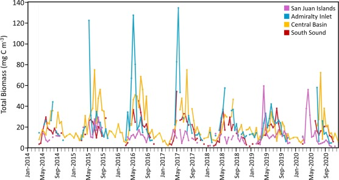

Supplementary figure 1. Total zooplankton biomass at each station.

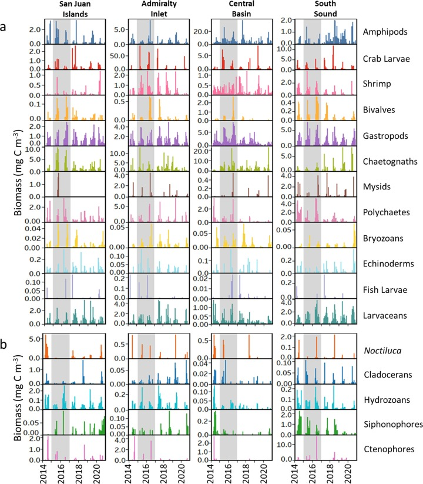

Supplementary figure 2. a) Biweekly biomass of taxa with mostly positive responses and b) mostly negative or mixed responses to the 2015-2016 Pacific marine heatwave.

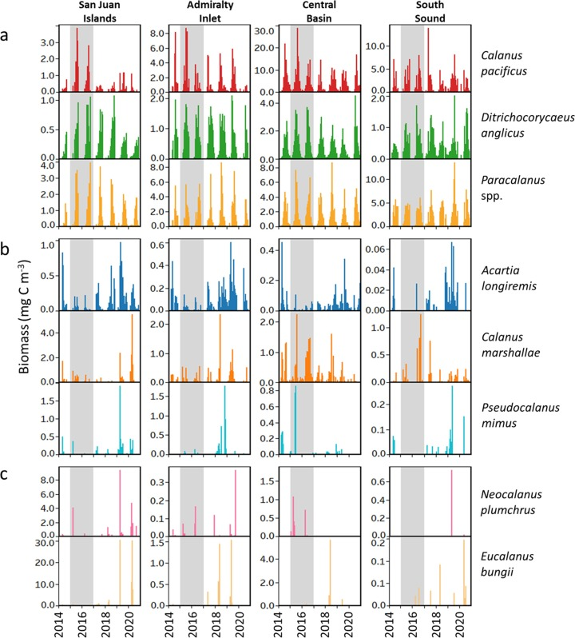

Supplementary figure 3. a) Biweekly biomass of Puget Sound resident copepod species, b) boreal copepod species, and c) subarctic copepod species by region.

[Download: Download Word document (17KB)](https://ars-els-cdn-com.reed.idm.oclc.org/content/image/1-s2.0-S0079661123000654-mmc1.docx)

Supplementary data 1.

## References

1. Araujo et al., 2013

   H.A. Araujo, C. Holt, J.M.R. Curtis, R.I. Perry, J.R. Irvine, C.G.J. Michielsens

   Building an ecosystem model using mismatched and fragmented data: a probabilistic network of early marine survival for coho salmon *Oncorhynchus kisutch* in the Strait of Georgia

   Prog. Oceanogr., 115 (2013), pp. 41-52, 10.1016/j.pocean.2013.05.022

   [View at publisher](https://doi.org/10.12816/0001912)[View in Scopus](https://www.scopus.com/inward/record.url?eid=2-s2.0-84959003732&partnerID=10&rel=R3.0.0)Google Scholar
2. Batten et al., 2018

   S.D. Batten, D.E. Raitsos, S. Danielson, R. Hopcroft, K. Coyle, A. McQuatters-Gollop

   Interannual variability in lower trophic levels on the Alaskan Shelf. Deep

   Res. Part II Top. Stud. Oceanogr., 147 (2018), pp. 58-68, 10.1016/j.dsr2.2017.04.023

   [View PDF](https://www-sciencedirect-com.reed.idm.oclc.org/science/article/pii/S0967064516302806/pdfft?md5=cbff480399d54fee2b2d5332d573ad88&pid=1-s2.0-S0967064516302806-main.pdf)[View article](https://www-sciencedirect-com.reed.idm.oclc.org/science/article/pii/S0967064516302806)[View in Scopus](https://www.scopus.com/inward/record.url?eid=2-s2.0-85020297260&partnerID=10&rel=R3.0.0)Google Scholar
3. Beamish et al., 2004

   R.J. Beamish, C. Mahnken, C.M. Neville

   Evidence that reduced early marine growth is associated with lower marine survival of coho salmon

   Trans. Am. Fish. Soc., 133 (2004), pp. 26-33, 10.1577/t03-028

   [View at publisher](https://ct.prod.getft.io/c2NpZW5jZWRpcmVjdF9jb250ZW50aG9zdGluZyx3aWxleSxodHRwczovL29ubGluZWxpYnJhcnkud2lsZXkuY29tL2RvaS9mdWxsLzEwLjE1NzcvVDAzLTAyOA.b_KSDDMpLTTwztj8xuMLNXoUZU9VXpDn-pxVLitCdGM)

   [View in Scopus](https://www.scopus.com/inward/record.url?eid=2-s2.0-0842263998&partnerID=10&rel=R3.0.0)Google Scholar
4. Bi et al., 2011a

   H. Bi, W.T. Peterson, J. Lamb, E. Casillas

   Copepods and salmon: characterizing the spatial distribution of juvenile salmon along the Washington and Oregon coast, USA

   Fish. Oceanogr., 20 (2011), pp. 125-138

   View at publisher

   [Crossref](https://doi.org/10.1111/j.1365-2419.2011.00573.x)[View in Scopus](https://www.scopus.com/inward/record.url?eid=2-s2.0-79751504582&partnerID=10&rel=R3.0.0)Google Scholar
5. Bi et al., 2011b

   H. Bi, W.T. Peterson, P.T. Strub

   Transport and coastal zooplankton communities in the northern California Current System

   Geophys. Res. Lett., 38 (2011), p. L12607, 10.1029/2011GL047927

   [View at publisher](https://ct.prod.getft.io/c2NpZW5jZWRpcmVjdF9jb250ZW50aG9zdGluZyx3aWxleSxodHRwOi8vd3d3LmFndS5vcmcvam91cm5hbHMvZ2wvZ2wxMTEyLzIwMTFHTDA0NzkyNy8yMDExR0wwNDc5MjcucGRm.wPc_tnpxCNbLMg6yIBBuAb8mmISFldF4_O4oXCzJkJ4)

   [View in Scopus](https://www.scopus.com/inward/record.url?eid=2-s2.0-79959717811&partnerID=10&rel=R3.0.0)Google Scholar
6. Bond et al., 2015

   N.A. Bond, M.F. Cronin, H. Freeland, N. Mantua

   Causes and impacts of the 2014 warm anomaly in the NE Pacific

   Geophys. Res. Lett., 42 (2015), pp. 3414-3420, 10.1002/2015GL063306

   View at publisher

   [View in Scopus](https://www.scopus.com/inward/record.url?eid=2-s2.0-84930478284&partnerID=10&rel=R3.0.0)Google Scholar
7. Bos, 2022

   J. Bos

   Standard operating procedure EAP088, version 1.1: Marine waters data quality assurance and quality control

   Washington State Department of Ecology, Olympia. (2022)

   https://apps.ecology.wa.gov/publications/SummaryPages/2303233.html. Publication 23–03-233. (Recertified 2022)

   Google Scholar
8. Bos and Keyzers, 2021

   Bos, J., Keyzers, M., 2021. Standard operating procedure EAP026, version 6.0: Chlorophyll a analysis. 23-03-231. Washington State Department of Ecology, Olympia. https://apps.ecology.wa.gov/publications/SummaryPages/2303231.html. (Recertified 2021).

   Google Scholar
9. Brodeur et al., 2019

   R.D. Brodeur, T.D. Auth, A.J. Phillips

   Major shifts in pelagic micronekton and macrozooplankton community structure in an upwelling ecosystem related to an unprecedented marine heatwave

   Front. Mar. Sci., 6 (2019), pp. 1-15, 10.3389/fmars.2019.00212

   [View at publisher](https://doi.org/10.1002/9781118929803.ewac0155)Google Scholar
10. Cannon and Laird, 1978

    Cannon, G.A., Laird, N.P., 1978. Variability of currents and water properties from year-long observations in a fjord estuary. In: Nihoul, J.C.J. (Ed.), Elsevier Oceanography Series. pp. 515–535. https://doi-org.reed.idm.oclc.org/10.1016/S0422-9894(08)71296-0.

    Google Scholar
11. Chandler et al., 2016

    Chandler, P.C., King, S.A., Perry, R.I., (Eds.), 2016. State of the physical, biological and selected fishery resources of Pacific Canadian marine ecosystems in 2015. Can. Tech. Rep. Fish. Aquat. Sci. 3179, viii + 230.

    Google Scholar
12. Chandler et al., 2017

    Chandler, P.C., King, S.A., Bolt, J., (Eds.), 2017. State of the physical, biological and selected fishery resources of Pacific Canadian marine ecosystems in 2016. Can. Tech. Rep. Fish. Aquat. Sci. 3225, vi +243.

    Google Scholar
13. Costalago et al., 2020

    D. Costalago, I. Forster, N. Nemcek, C. Neville, R.I. Perry, K. Young, B.P.V. Hunt

    Seasonal and spatial dynamics of the planktonic trophic biomarkers in the Strait of Georgia (northeast Pacific) and implications for fish

    Sci. Rep., 10 (2020), pp. 1-12, 10.1038/s41598-020-65557-1

    View at publisher

    Google Scholar
14. Cross et al., 2009

    A.D. Cross, D.A. Beauchamp, J.H. Moss, K.W. Myers

    Interannual variability in early marine growth, size-selective mortality, and marine survival for Prince William Sound pink salmon

    Mar. Coast. Fish., 1 (2009), pp. 57-70, 10.1577/c08-005.1

    [View at publisher](https://ct.prod.getft.io/c2NpZW5jZWRpcmVjdF9jb250ZW50aG9zdGluZyx3aWxleSxodHRwczovL29ubGluZWxpYnJhcnkud2lsZXkuY29tL2RvaS9wZGYvMTAuMTU3Ny9DMDgtMDA1LjE.EjFtaeDePtssQ3_EEjzFVbXk35fTK5xifSvgOjgI5bg)

    [View in Scopus](https://www.scopus.com/inward/record.url?eid=2-s2.0-84858137107&partnerID=10&rel=R3.0.0)Google Scholar
15. Di Lorenzo and Mantua, 2016

    E. Di Lorenzo, N.J. Mantua

    Multi-year persistence of the 2014–15 North Pacific marine heatwave

    Nat. Clim. Chang., 6 (2016), p. 1042, 10.1038/nclimate3082

    [View at publisher](https://ct.prod.getft.io/c2NpZW5jZWRpcmVjdF9jb250ZW50aG9zdGluZyxzcHJpbmdlcixodHRwOi8vd3d3Lm5hdHVyZS5jb20vYXJ0aWNsZXMvbmNsaW1hdGUzMDgyLnBkZg.XZAjguKXZtpQA-fPXvXleVUXK8IXSmOrpSgT9HZvyd8)

    [View in Scopus](https://www.scopus.com/inward/record.url?eid=2-s2.0-84992660453&partnerID=10&rel=R3.0.0)[Google Scholar](https://scholar.google.com/scholar_lookup?title=Multi-year%20persistence%20of%20the%20201415%20North%20Pacific%20marine%20heatwave&publication_year=2016&author=E.%20Di%20Lorenzo&author=N.J.%20Mantua)
16. Duffy and Beauchamp, 2011

    E.J. Duffy, D.A. Beauchamp

    Rapid growth in the early marine period improves the marine survival of Chinook salmon (*Oncorhynchus tshawytscha*) in Puget Sound, Washington

    Can. J. Fish. Aquat. Sci., 68 (2011), pp. 232-240, 10.1139/F10-144

    [View at publisher](https://doi.org/10.1139/F10-144)[View in Scopus](https://www.scopus.com/inward/record.url?eid=2-s2.0-79551661171&partnerID=10&rel=R3.0.0)Google Scholar
17. Farkas, 1971

    T. Farkas

    A possible explanation for the differences in the fatty acid composition of fresh-water and marine fishes

    Ann. Inst. Biol. (Tihany) Hung. Acad. Sci. (1971), pp. 143-152

    Google Scholar
18. Farkas, 1979

    T. Farkas

    Adaptation of fatty acid compositions to temperature-a study on planktonic crustaceans

    Comp. Biochem. Physiol., 64B (1979), pp. 71-76, 10.1016/0305-0491(79)90185-8

    [View PDF](https://www-sciencedirect-com.reed.idm.oclc.org/science/article/pii/0305049179901858/pdf?md5=2184357c0efdfb722998a8a22b1596cf&pid=1-s2.0-0305049179901858-main.pdf)[View article](https://www-sciencedirect-com.reed.idm.oclc.org/science/article/pii/0305049179901858)[View in Scopus](https://www.scopus.com/inward/record.url?eid=2-s2.0-0002715633&partnerID=10&rel=R3.0.0)[Google Scholar](https://scholar.google.com/scholar_lookup?title=Adaptation%20of%20fatty%20acid%20compositions%20to%20temperature-a%20study%20on%20planktonic%20crustaceans&publication_year=1979&author=T.%20Farkas)
19. Fisher et al., 2020

    J. Fisher, D. Kimmel, T. Ross, S. Batten, E. Bjorkstedt, M. Galbraith, K. Jacobson, J. Keister, A. Sastri, K. Suchy, S. Zeman, R.I. Perry

    Copepod responses to, and recovery from, the recent marine heatwave in the Northeast Pacific

    PICES Press, 28 (2020), pp. 65-71

    Google Scholar
20. Ford et al., 2010

    J.K.B. Ford, G.M. Ellis, P.F. Olesiuk, K.C. Balcomb

    Linking killer whale survival and prey abundance: Food limitation in the oceans’ apex predator?

    Biol. Lett., 6 (2010), pp. 139-142, 10.1098/rsbl.2009.0468

    View at publisher

    [View in Scopus](https://www.scopus.com/inward/record.url?eid=2-s2.0-77449111253&partnerID=10&rel=R3.0.0)Google Scholar
21. Glencross, 2009

    B.D. Glencross

    Exploring the nutritional demand for essential fatty acids by aquaculture species

    Rev. Aquac., 1 (2009), pp. 71-124, 10.1111/j.1753-5131.2009.01006.x

    View at publisher

    [View in Scopus](https://www.scopus.com/inward/record.url?eid=2-s2.0-85137895639&partnerID=10&rel=R3.0.0)[Google Scholar](https://scholar.google.com/scholar_lookup?title=Exploring%20the%20nutritional%20demand%20for%20essential%20fatty%20acids%20by%20aquaculture%20species&publication_year=2009&author=B.D.%20Glencross)
22. Graham et al., 2001

    W.M. Graham, F. Pagès, W.M. Hamner

    A physical context for gelatinous zooplankton aggregations: a review

    Hydrobiologia, 451 (2001), pp. 199-212, 10.1023/A:1011876004427

    [View at publisher](https://doi.org/10.1023/A:1011876004427)[View in Scopus](https://www.scopus.com/inward/record.url?eid=2-s2.0-0035872269&partnerID=10&rel=R3.0.0)Google Scholar
23. Helenius et al., 2020

    L. Helenius, S.M. Budge, H. Nadeau, C.L. Johnson

    Ambient temperature and algal prey type affect essential fatty acid incorporation and trophic upgrading in a herbivorous marine copepod

    Philos. Trans. R. Soc. B Biol. Sci., 375 (2020), 10.1098/rstb.2020.0039

    View at publisher

    Google Scholar
24. Hiltunen et al., 2021

    M. Hiltunen, U. Strandberg, M.T. Brett, A.K. Winans, D.A. Beauchamp, M. Kotila, J.E. Keister

    Taxonomic, temporal, and spatial variations in zooplankton fatty acid composition in Puget Sound, WA, USA

    Estuaries Coasts, 45 (2021), pp. 567-581, 10.1007/s12237-021-00973-8

    View at publisher

    Google Scholar
25. Hipfner et al., 2020

    M.J. Hipfner, M.D. Galbraith, D.F. Bertram, D.J. Green

    Basin-scale oceanographic processes, zooplankton community structure, and diet and reproduction of a sentinel North Pacific seabird over a 22-year period

    Prog. Oceanogr., 182 (2020), p. 102290, 10.1016/j.pocean.2020.102290

    View at publisher

    Google Scholar
26. Hixson and Arts, 2016

    S.M. Hixson, M.T. Arts

    Climate warming is predicted to reduce omega-3, long-chain, polyunsaturated fatty acid production in phytoplankton

    Glob. Chang. Biol., 22 (2016), pp. 2744-2755, 10.1111/gcb.13295

    View at publisher

    [View in Scopus](https://www.scopus.com/inward/record.url?eid=2-s2.0-85027933268&partnerID=10&rel=R3.0.0)Google Scholar
27. Huntley and Lopez, 1992

    M.E. Huntley, M.D.G. Lopez

    Temperature-dependent production of marine copepods: a global synthesis

    Am. Nat., 140 (1992), pp. 201-242

    [View in Scopus](https://www.scopus.com/inward/record.url?eid=2-s2.0-0027063869&partnerID=10&rel=R3.0.0)[Google Scholar](https://scholar.google.com/scholar_lookup?title=Temperature-dependent%20production%20of%20marine%20copepods%3A%20a%20global%20synthesis&publication_year=1992&author=M.E.%20Huntley&author=M.D.G.%20Lopez)
28. Jacox et al., 2019

    M. Jacox, D. Tommasi, M. Alexander, G. Hervieux, C. Stock

    Predicting the evolution of the 2014–16 California Current System marine heatwave from an ensemble of coupled global climate forecasts

    Front. Mar. Sci., 6 (2019), pp. 1-14, 10.3389/fmars.2019.00497

    [View at publisher](https://doi.org/10.1201/9780429066276-1)Google Scholar
29. Keister et al., 2011

    J.E. Keister, E. Di Lorenzo, C.A. Morgan, V. Combes, W.T. Peterson

    Zooplankton species composition is linked to ocean transport in the Northern California Current

    Glob. Chang. Biol., 17 (2011), pp. 2498-2511, 10.1111/j.1365-2486.2010.02383.x

    View at publisher

    [View in Scopus](https://www.scopus.com/inward/record.url?eid=2-s2.0-79957791844&partnerID=10&rel=R3.0.0)Google Scholar
30. Keister et al., 2022

    J.E. Keister, B. Herrmann, J. Bos

    Zooplankton composition links to climate and salmon survival in a northern temperate fjord

    Limnol. Oceanogr., 9999 (2022), pp. 1-16, 10.1002/lno.12208

    [View at publisher](https://ct.prod.getft.io/c2NpZW5jZWRpcmVjdF9jb250ZW50aG9zdGluZyx3aWxleSxodHRwczovL29ubGluZWxpYnJhcnkud2lsZXkuY29tL2RvaS9wZGYvMTAuMTAwMi9sbm8uMTIyMDg.xTQq2o94xU765wdlarZJVS9eTTHYe4PqDeUQkPLtL4s)

    Google Scholar
31. Khangaonkar et al., 2021

    T. Khangaonkar, A. Nugraha, S.K. Yun, L. Premathilake, J.E. Keister, J. Bos

    Propagation of the 2014–2016 Northeast Pacific marine heatwave through the Salish Sea

    Front. Mar. Sci., 8 (2021), 10.3389/fmars.2021.787604

    [View at publisher](https://doi.org/10.3389/fmars.2021.787604)Google Scholar
32. King County, 2020

    King County

    Marine offshore and beach water monitoring: Sampling and analysis plan

    Seattle, Washington, Prepared by Kimberle Stark, Water and Land Resources Division (2020)

    [Google Scholar](https://scholar.google.com/scholar_lookup?title=Marine%20offshore%20and%20beach%20water%20monitoring%3A%20Sampling%20and%20analysis%20plan&publication_year=2020&author=King%20County)
33. Lavaniegos and Ohman, 2007

    B.E. Lavaniegos, M.D. Ohman

    Coherence of long-term variations of zooplankton in two sectors of the California Current System

    Prog. Oceanogr., 75 (2007), pp. 42-69, 10.1016/j.pocean.2007.07.002

    [View PDF](https://www-sciencedirect-com.reed.idm.oclc.org/science/article/pii/S0079661107001334/pdfft?md5=dc12a6ee29a1735dddec515e685382e5&pid=1-s2.0-S0079661107001334-main.pdf)[View article](https://www-sciencedirect-com.reed.idm.oclc.org/science/article/pii/S0079661107001334)[View in Scopus](https://www.scopus.com/inward/record.url?eid=2-s2.0-34548638401&partnerID=10&rel=R3.0.0)Google Scholar
34. Lavaniegos et al., 2019

    B.E. Lavaniegos, M. Jiménez-Herrera, I. Ambriz-Arreola

    Unusually low euphausiid biomass during the warm years of 2014–2016 in the transition zone of the California Current

    Deep. Res. Part II Top. Stud. Oceanogr., 169–170 (2019), Article 104638, 10.1016/j.dsr2.2019.104638

    [View PDF](https://www-sciencedirect-com.reed.idm.oclc.org/science/article/pii/S0967064518302443/pdfft?md5=05b84c1bd26508f16fc970991cedb0ac&pid=1-s2.0-S0967064518302443-main.pdf)[View article](https://www-sciencedirect-com.reed.idm.oclc.org/science/article/pii/S0967064518302443)[View in Scopus](https://www.scopus.com/inward/record.url?eid=2-s2.0-85071485740&partnerID=10&rel=R3.0.0)Google Scholar
35. Lilly and Ohman, 2018

    L.E. Lilly, M.D. Ohman

    CCE IV: El Niño-related zooplankton variability in the southern California Current System. Deep

    Res. Part I Oceanogr. Res. Pap., 140 (2018), pp. 36-51, 10.1016/j.dsr.2018.07.015

    [View PDF](https://www-sciencedirect-com.reed.idm.oclc.org/science/article/pii/S096706371830027X/pdfft?md5=f49e0b326c61d172b6f09b33dbb2cac1&pid=1-s2.0-S096706371830027X-main.pdf)[View article](https://www-sciencedirect-com.reed.idm.oclc.org/science/article/pii/S096706371830027X)[View in Scopus](https://www.scopus.com/inward/record.url?eid=2-s2.0-85052760398&partnerID=10&rel=R3.0.0)Google Scholar
36. Lilly and Ohman, 2021

    L.E. Lilly, M.D. Ohman

    Euphausiid spatial displacements and habitat shifts in the southern California Current System in response to El Niño variability

    Prog. Oceanogr., 193 (2021), Article 102544, 10.1016/j.pocean.2021.102544

    [View PDF](https://www-sciencedirect-com.reed.idm.oclc.org/science/article/pii/S0079661121000343/pdfft?md5=eb36f4f1fef7fc85afafe72be82db6be&pid=1-s2.0-S0079661121000343-main.pdf)[View article](https://www-sciencedirect-com.reed.idm.oclc.org/science/article/pii/S0079661121000343)[View in Scopus](https://www.scopus.com/inward/record.url?eid=2-s2.0-85103257975&partnerID=10&rel=R3.0.0)Google Scholar
37. Mackas and Beaugrand, 2010

    D.L. Mackas, G. Beaugrand

    Comparisons of zooplankton time series

    J. Mar. Syst., 79 (2010), pp. 286-304, 10.1016/j.jmarsys.2008.11.030

    [View PDF](https://www-sciencedirect-com.reed.idm.oclc.org/science/article/pii/S0924796309000852/pdfft?md5=606c1eb96e0396f63d01eb770c5848d3&pid=1-s2.0-S0924796309000852-main.pdf)[View article](https://www-sciencedirect-com.reed.idm.oclc.org/science/article/pii/S0924796309000852)[View in Scopus](https://www.scopus.com/inward/record.url?eid=2-s2.0-70649087276&partnerID=10&rel=R3.0.0)[Google Scholar](https://scholar.google.com/scholar_lookup?title=Comparisons%20of%20zooplankton%20time%20series&publication_year=2010&author=D.L.%20Mackas&author=G.%20Beaugrand)
38. Mackas et al., 2001

    D.L. Mackas, R.E. Thomson, M.D. Galbraith

    Changes in the zooplankton community of the British Columbia continental margin, 1985–1999, and their covariation with oceanographic conditions

    Can. J. Fish. Aquat. Sci., 58 (2001), pp. 685-702, 10.1139/f01-009

    [View at publisher](https://doi.org/10.1139/f01-009)[View in Scopus](https://www.scopus.com/inward/record.url?eid=2-s2.0-0035058328&partnerID=10&rel=R3.0.0)Google Scholar
39. Mackas et al., 2006

    D.L. Mackas, W.T. Peterson, M.D. Ohman, B.E. Lavaniegos

    Zooplankton anomalies in the California Current System before and during the warm ocean conditions of 2005

    Geophys. Res. Lett., 33 (2006), 10.1029/2006GL027930

    View at publisher

    Google Scholar
40. Martens and Van Beusekom, 2008

    P. Martens, J.E.E. Van Beusekom

    Zooplankton response to a warmer northern Wadden Sea

    Helgol. Mar. Res., 62 (2008), pp. 67-75, 10.1007/s10152-007-0097-0

    View at publisher

    [View in Scopus](https://www.scopus.com/inward/record.url?eid=2-s2.0-39649114571&partnerID=10&rel=R3.0.0)[Google Scholar](https://scholar.google.com/scholar_lookup?title=Zooplankton%20response%20to%20a%20warmer%20northern%20Wadden%20Sea&publication_year=2008&author=P.%20Martens&author=J.E.E.%20Van%20Beusekom)
41. McClatchie et al., 2016

    S. McClatchie, R. Goericke, A. Leising, T.D. Auth, E. Bjorkstedt, R.R. Robertson, R.D. Brodeur, X. Du, E.A. Daly, C.A. Morgan, F.P. Chavez, A.J. Debich, J. Hildebrand, J. Field, K. Sakuma, M.G. Jacox, M. Kahru, R. Kudela, C. Anderson, B.E. Lavaniegos, J. Gomez-Valdes, S.P.A. Jiménez-Rosenberg, R. McCabe, S.R. Melin, M.D. Ohman, L.M. Sala, W.T. Peterson, J. Fisher, I.D. Schroeder, S.J. Bograd, E.L. Hazen, S.R. Schneider, R.T. Golightly, R.M. Suryan, A.J. Gladics, S. Loredo, J.M. Porquez, A.R. Thompson, E.D. Weber, W. Watson, V. Trainer, P. Warzybok, R. Bradley, J. Jahncke

    State of the California Current 2015–16: comparisons with the 1997–98 El Niño

    Calif. Coop. Ocean. Fish. Investig. Reports, 57 (2016), pp. 1-57

    Google Scholar
42. McKinstry et al., 2022

    C.A.E. McKinstry, R.W. Campbell, K. Holderied

    Influence of the 2014–2016 marine heatwave on seasonal zooplankton community structure and abundance in the lower Cook Inlet, Alaska

    Deep. Res. Part II Top. Stud. Oceanogr., 195 (2022), 10.1016/j.dsr2.2021.105012

    View at publisher

    Google Scholar
43. Moore et al., 2008

    S.K. Moore, N.J. Mantua, J.P. Kellogg, J.A. Newton

    Local and large-scale climate forcing of Puget Sound oceanographic properties on seasonal to interdecadal timescales

    Limnol. Oceanogr., 53 (2008), pp. 1746-1758, 10.4319/lo.2008.53.5.1746

    View at publisher

    [View in Scopus](https://www.scopus.com/inward/record.url?eid=2-s2.0-52149086308&partnerID=10&rel=R3.0.0)Google Scholar
44. Morgan et al., 2019

    C.A. Morgan, B.R. Beckman, L.A. Weitkamp, K.L. Fresh

    Recent ecosystem disturbance in the Northern California Current

    Fisheries, 44 (2019), pp. 465-474, 10.1002/fsh.10273

    View at publisher

    [View in Scopus](https://www.scopus.com/inward/record.url?eid=2-s2.0-85067685305&partnerID=10&rel=R3.0.0)Google Scholar
45. Ohman et al., 1998

    M.D. Ohman, A.V. Drits, M.E. Clarke, S. Plourde

    Differential dormancy of co-occurring copepods. Deep

    Res. Part II Top. Stud. Oceanogr., 45 (1998), pp. 1709-1740, 10.1016/S0967-0645(98)80014-3

    [View PDF](https://www-sciencedirect-com.reed.idm.oclc.org/science/article/pii/S0967064598800143/pdf?md5=053a88ce0878d1002cba8da102041e13&pid=1-s2.0-S0967064598800143-main.pdf)[View article](https://www-sciencedirect-com.reed.idm.oclc.org/science/article/pii/S0967064598800143)[View in Scopus](https://www.scopus.com/inward/record.url?eid=2-s2.0-0032142669&partnerID=10&rel=R3.0.0)Google Scholar
46. Osgood and Frost, 1994

    K.E. Osgood, B.W. Frost

    Comparative life histories of three species of planktonic calanoid copepods in Dabob Bay

    Washington. Mar. Biol., 118 (1994), pp. 627-636, 10.1007/BF00347510

    [View at publisher](https://doi.org/10.1007/BF00347510)[View in Scopus](https://www.scopus.com/inward/record.url?eid=2-s2.0-0028554921&partnerID=10&rel=R3.0.0)Google Scholar
47. Perry et al., 2021

    Perry, R.I., Young, K., Galbraith, M.D., Chandler, P.C., Velez-Espino, A., Baillie, S., 2021. Zooplankton variability in the Strait of Georgia, Canada, and relationships with marine survivals of Chinook and coho salmon. PLoS One 16. https://doi-org.reed.idm.oclc.org/e0245941.

    Google Scholar
48. Peterson et al., 2017

    W.T. Peterson, J.L. Fisher, P.T. Strub, X. Du, C. Risien, J.O. Peterson, C.T. Shaw

    The pelagic ecosystem in the northern California Current off Oregon during the 2014–2016 warm anomalies within the context of the past 20 year

    J. Geophys. Res. Ocean. Res., 122 (2017), pp. 7267-7290, 10.1002/2017JC012952

    View at publisher

    [View in Scopus](https://www.scopus.com/inward/record.url?eid=2-s2.0-85031502448&partnerID=10&rel=R3.0.0)Google Scholar
49. Pond, 2012

    D.W. Pond

    The physical properties of lipids and their role in controlling the distribution of zooplankton in the oceans

    J. Plankton Res., 34 (2012), pp. 443-453, 10.1093/plankt/fbs027

    View at publisher

    [View in Scopus](https://www.scopus.com/inward/record.url?eid=2-s2.0-84860485452&partnerID=10&rel=R3.0.0)Google Scholar
50. PSEMP Marine Waters Workgroup, 2015

    PSEMP Marine Waters Workgroup, 2015. Puget Sound marine waters: 2014 overview. S. K. Moore, R. Wold, K. Stark, J. Bos, P. Williams, K. Dzinbal, C. Krembs and J. Newton (Eds.). www.psp.wa.gov/PSmarinewatersoverview.php.

    Google Scholar
51. PSEMP Marine Waters Workgroup, 2016

    PSEMP Marine Waters Workgroup, 2016. Puget Sound marine waters: 2015 overview. S. K. Moore, R. Wold, K. Stark, J. Bos, P. Williams, K. Dzinbal, C. Krembs and J. Newton (Eds.). www.psp.wa.gov/PSmarinewatersoverview.php.

    Google Scholar
52. PSEMP Marine Waters Workgroup, 2017

    PSEMP Marine Waters Workgroup, 2017. Puget Sound marine waters: 2016 overview. S. K. Moore, R. Wold, K. Stark, J. Bos, P. Williams, N. Hamel, A. Edwards, C. Krembs, and J. Newton, (Eds.). www.psp.wa.gov/PSmarinewatersoverview.php.

    Google Scholar
53. PSEMP Marine Waters Workgroup, 2021

    PSEMP Marine Waters Workgroup, 2021. Puget Sound marine waters: 2020 overview. J. Apple, R. Wold, K. Stark, J. Bos, P. Williams, N. Hamel, S. Yang, J. Selleck, S. K. Moore, J. Rice, S. Kantor, C. Krembs, G. Hannach, and J. Newton (Eds). www.psp.wa.gov/PSmarinewatersoverview.php.

    Google Scholar
54. Pugh, 1999

    P.R. Pugh

    A review of the genus *Bargmannia* Totton, 1954 (Siphonophorae, Physonecta, Pyrostephidae). Bull. Nat. Hist. Museum

    London (Zoology Ser.), 65 (1999), pp. 51-72

    [Google Scholar](https://scholar.google.com/scholar_lookup?title=A%20review%20of%20the%20genus%20Bargmannia%20Totton%2C%201954%20.%20Bull.%20Nat.%20Hist.%20Museum&publication_year=1999&author=P.R.%20Pugh)
55. Purcell, 2005

    J.E. Purcell

    Climate effects on formation of jellyfish and ctenophore blooms: a review

    J. Mar. Biol. Assoc. United Kingdom, 85 (2005), pp. 461-476, 10.1017/S0025315405011409

    [View at publisher](https://doi.org/10.1017/S0025315405011409)[View in Scopus](https://www.scopus.com/inward/record.url?eid=2-s2.0-22744448919&partnerID=10&rel=R3.0.0)[Google Scholar](https://scholar.google.com/scholar_lookup?title=Climate%20effects%20on%20formation%20of%20jellyfish%20and%20ctenophore%20blooms%3A%20a%20review&publication_year=2005&author=J.E.%20Purcell)
56. Ruyter et al., 2000

    B. Ruyter, C. Røsjø, O. Einen, M.S. Thomassen

    Essential fatty acids in Atlantic salmon: effects of increasing dietary doses of n-6 and n-3 fatty acids on growth, survival and fatty acid composition of liver, blood and carcass

    Aquac. Nutr., 6 (2000), pp. 119-127

    Google Scholar
57. Schlechtriem et al., 2006

    C. Schlechtriem, M.T. Arts, I.D. Zellmer

    Effect of temperature on the fatty acid composition and temporal trajectories of fatty acids in fasting *Daphnia pulex* (Crustacea, Cladocera)

    Lipids, 41 (2006), pp. 397-400, 10.1007/s11745-006-5111-9

    [View at publisher](https://ct.prod.getft.io/c2NpZW5jZWRpcmVjdF9jb250ZW50aG9zdGluZyx3aWxleSxodHRwczovL29ubGluZWxpYnJhcnkud2lsZXkuY29tL2RvaS9mdWxsLzEwLjEwMDcvczExNzQ1LTAwNi01MTExLTk.vw5XUe1IQ6YYopYbW-UBsxR6KgPXqhTntWXSI0yMDBE)

    [View in Scopus](https://www.scopus.com/inward/record.url?eid=2-s2.0-33745177787&partnerID=10&rel=R3.0.0)Google Scholar
58. Sherlock and Robison, 2000

    R.E. Sherlock, B.H. Robison

    Effects of temperature on the development and survival of *Nanomia bijuga* (Hydrozoa, Siphonophora)

    Invertebr. Biol., 119 (2000), pp. 379-385, 10.1111/j.1744-7410.2000.tb00106.x

    View at publisher

    [View in Scopus](https://www.scopus.com/inward/record.url?eid=2-s2.0-0034361326&partnerID=10&rel=R3.0.0)Google Scholar
59. Suchman et al., 2012

    C.L. Suchman, R.D. Brodeur, E.A. Daly, R.L. Emmett

    Large medusae in surface waters of the Northern California Current: Variability in relation to environmental conditions

    Hydrobiologia, 690 (2012), pp. 113-125, 10.1007/s10750-012-1055-7

    [View at publisher](https://ct.prod.getft.io/c2NpZW5jZWRpcmVjdF9jb250ZW50aG9zdGluZyxzcHJpbmdlcixodHRwOi8vbGluay5zcHJpbmdlci5jb20vY29udGVudC9wZGYvMTAuMTAwNy9zMTA3NTAtMDEyLTEwNTUtNy5wZGY._h-92zyBOE3chIPvJhLdtzZqAx7Vw6hcInSIkkrVJ1Q)

    [View in Scopus](https://www.scopus.com/inward/record.url?eid=2-s2.0-84861670619&partnerID=10&rel=R3.0.0)Google Scholar
60. Uye, 1982

    S. Uye

    Length-weight relationships of important zooplankton from the inland Sea of Japan

    J. Oceanogr. Soc. Japan, 38 (1982), pp. 149-158

    [View in Scopus](https://www.scopus.com/inward/record.url?eid=2-s2.0-0020424069&partnerID=10&rel=R3.0.0)[Google Scholar](https://scholar.google.com/scholar_lookup?title=Length-weight%20relationships%20of%20important%20zooplankton%20from%20the%20inland%20Sea%20of%20Japan&publication_year=1982&author=S.%20Uye)
61. Van der Have and De Jong, 1996

    T.M. Van der Have, G. De Jong

    Adult size in ectotherms: temperature effects on growth and differentiation

    J. Theor. Biol., 183 (1996), pp. 329-340

    [View PDF](https://www-sciencedirect-com.reed.idm.oclc.org/science/article/pii/S0022519396902246/pdf?md5=87a2807a5fecd0023c8b3cb007967bfc&pid=1-s2.0-S0022519396902246-main.pdf)[View article](https://www-sciencedirect-com.reed.idm.oclc.org/science/article/pii/S0022519396902246)[View in Scopus](https://www.scopus.com/inward/record.url?eid=2-s2.0-0030574420&partnerID=10&rel=R3.0.0)Google Scholar
62. Washington Department of Fish and Wildlife, 2019

    Washington Department of Fish and Wildlife, 2019. 2016 Washington State herring stock status report. Prepared by T. Sandell, A. Lindquist, P. Dionne, and D. Lowry, Fish Program, Fish Management Division.

    Google Scholar
63. Webber and Roff, 1995

    M.K. Webber, J.C. Roff

    Annual biomass and production of the oceanic copepod community off Discovery Bay

    Jamaica. Mar. Biol., 123 (1995), pp. 481-495, 10.1108/eb026408

    [View at publisher](https://doi.org/10.1108/eb026408)[View in Scopus](https://www.scopus.com/inward/record.url?eid=2-s2.0-0029414683&partnerID=10&rel=R3.0.0)Google Scholar
64. Williams and Robins, 1979

    R. Williams, D. Robins

    Calorific, ash, carbon and nitrogen content in relation to length and dry weight of *Parathemisto gaudichaudi* (Amphipoda: Hyperiidea) in the North East Atlantic Ocean

    Mar. Biol., 52 (1979), pp. 247-252, 10.1007/BF00398138

    [View in Scopus](https://www.scopus.com/inward/record.url?eid=2-s2.0-0001336213&partnerID=10&rel=R3.0.0)Google Scholar
65. Xu et al., 1994

    X.L. Xu, W.J. Ji, J.D. Castell, R.K. O’Dor

    Essential fatty acid requirement of the Chinese prawn, *Penaeus chinensis*

    Aquaculture, 127 (1994), pp. 29-40, 10.1016/0044-8486(94)90189-9

    [View PDF](https://www-sciencedirect-com.reed.idm.oclc.org/science/article/pii/0044848694901899/pdf?md5=663f6f7c3d2872c89b6d29e8322135bc&pid=1-s2.0-0044848694901899-main.pdf)[View article](https://www-sciencedirect-com.reed.idm.oclc.org/science/article/pii/0044848694901899)[View in Scopus](https://www.scopus.com/inward/record.url?eid=2-s2.0-0027975219&partnerID=10&rel=R3.0.0)Google Scholar
66. Zaba and Rudnick, 2016

    K.D. Zaba, D.L. Rudnick

    The 2014–2015 warming anomaly in the Southern California Current System observed by underwater gliders

    Geophys. Res. Lett., 43 (2016), pp. 1241-1248, 10.1002/2015GL067550

    [View in Scopus](https://www.scopus.com/inward/record.url?eid=2-s2.0-84975732652&partnerID=10&rel=R3.0.0)Google Scholar

## Cited by (3)

### [Hidden underlying mechanisms for changes in mesozooplankton communities: Transport and eddy driven changes](https://www-sciencedirect-com.reed.idm.oclc.org/science/article/pii/S004896972404484X)

- 2024, Science of the Total Environment

### [Environmental drivers of mesozooplankton dynamics in the Munroe Island, adjacent to Ashtamudi Estuary, India](https://doi.org/10.1007/s10661-024-13129-5)

- 2024, Environmental Monitoring and Assessment

### [Spatiotemporal variation in clam recruitment among beaches in Washington State (USA)](https://doi.org/10.1111/maec.12790)

- 2024, Marine Ecology

© 2023 The Authors. Published by Elsevier Ltd.

- Progress in Oceanography, Volume 219, 2023, Article 103155

  Kunito Yamamae, …, Atsushi Yamaguchi

  [View PDF](https://www-sciencedirect-com.reed.idm.oclc.org/science/article/pii/S0079661123001982/pdfft?md5=eed6d2d57715536a97efd90056b9bd17&pid=1-s2.0-S0079661123001982-main.pdf)

- Progress in Oceanography, Volume 188, 2020, Article 102436

  Christian Briseño-Avena, …, Robert K. Cowen

  [View PDF](https://www-sciencedirect-com.reed.idm.oclc.org/science/article/pii/S0079661120301750/pdfft?md5=2c3ecba36d40dc71883950645429db4f&pid=1-s2.0-S0079661120301750-main.pdf)

- Progress in Oceanography, Volume 186, 2020, Article 102378

  Emily Fergusson, …, Haila Schultz

  [View PDF](https://www-sciencedirect-com.reed.idm.oclc.org/science/article/pii/S0079661120301178/pdfft?md5=aa9fa37ee82066e5300cd00fd2341d20&pid=1-s2.0-S0079661120301178-main.pdf)

- Citation Indexes: 3

- Readers: 18